# ECON 409: Final Project

#### Courtney Manhart, Tanner Woods, Lindsay Mahowald, and Martin Jamouss

```python
pip install yfinance
```

[output not shown]

```python
pip install simple_colors
```

```python
# Import Necessary Packages
import yfinance as yf
import matplotlib.pyplot as plt
import pandas as pd
import numpy as np
import datetime
import io
import matplotlib.lines as mlines
import statsmodels.formula.api as smf
from statsmodels.tsa.arima.model import ARIMA
import scipy.stats as st
import warnings
%matplotlib inline
warnings.filterwarnings('ignore')
import seaborn as sns
from simple_colors import *

from statsmodels.graphics.tsaplots import plot_acf, plot_pacf
from statsmodels.tsa.arima_process import ArmaProcess
# import pmdarima as pm
from statsmodels.graphics.tsaplots import plot_predict
```

```python
from google.colab import drive
drive.mount('/content/gdrive/', force_remount=True)
```

### **Import the Data**: Choose one or more series of economic fundamentals to use for generating exchange rate forecasts. The forecasts of the asset price may be directional or point forecasts

###### *Economic Fundamentals of Interest*: Interest Rate, Inflation, Unemployment (CHOOSE WHICH ONES TO USE or all)

```python
# The following data includes:
    # US & UK interest rates
    # US & UK inflation rates
    # US & UK unemployment rates
    # Exchange Rate of the US dollar and British Pound

data = pd.read_csv('/content/gdrive/MyDrive/409 Final Project/final_project_data.csv', index_col = 0, parse_dates = True)
data.head()
```

|  | United States Interest | United Kingdom Interest | United States Inflation | United Kingdom Inflation | United States Unemployment | United Kingdom Unemployment | DEXUSUK |
| --- | --- | --- | --- | --- | --- | --- | --- |
| 1983-02-01 | 8.54 | 11.3338 | 0.037076 | 0.049259 | 10.4 | 10.7 | 1.5115 |
| 1983-03-01 | 8.69 | 10.9757 | 0.034847 | 0.053428 | 10.4 | 10.8 | 1.4825 |
| 1983-04-01 | 8.63 | 10.2616 | 0.035903 | 0.046267 | 10.3 | 10.8 | 1.5573 |
| 1983-05-01 | 8.49 | 10.2593 | 0.040000 | 0.040038 | 10.2 | 11.0 | 1.6005 |
| 1983-06-01 | 9.20 | 9.9384 | 0.034411 | 0.036957 | 10.1 | 10.9 | 1.5330 |

```python
# Import Risk-Free Rate from the treasurey yields
rf_rate = pd.read_csv('/content/gdrive/MyDrive/409 Final Project/1-year-treasury-rate-yield-chart.csv',
                       index_col = 0, parse_dates = True).ffill()
rf_rate.columns = ['rfr']

### The Risk-Free Rates are an annual rate based on the price
### of the 1-year Treasure Bond on the given day. So to to get
### Monthly risk-free rates we need to:
    ## i_m = [(1 + i_a) **(1/12)] - 1
# Note: We want Monthly since our data is monhtly

rf_rate = (((rf_rate / 100) + 1) ** (1/12)) - 1



# Adding the Risk-Free Rate to our DataFrame
data = pd.merge_asof(data, rf_rate, left_index = True,
                     right_index = True)
data.head()
```

|  | United States Interest | United Kingdom Interest | United States Inflation | United Kingdom Inflation | United States Unemployment | United Kingdom Unemployment | DEXUSUK | rfr |
| --- | --- | --- | --- | --- | --- | --- | --- | --- |
| 1983-02-01 | 8.54 | 11.3338 | 0.037076 | 0.049259 | 10.4 | 10.7 | 1.5115 | 0.007153 |
| 1983-03-01 | 8.69 | 10.9757 | 0.034847 | 0.053428 | 10.4 | 10.8 | 1.4825 | 0.006883 |
| 1983-04-01 | 8.63 | 10.2616 | 0.035903 | 0.046267 | 10.3 | 10.8 | 1.5573 | 0.007469 |
| 1983-05-01 | 8.49 | 10.2593 | 0.040000 | 0.040038 | 10.2 | 11.0 | 1.6005 | 0.007015 |
| 1983-06-01 | 9.20 | 9.9384 | 0.034411 | 0.036957 | 10.1 | 10.9 | 1.5330 | 0.007507 |

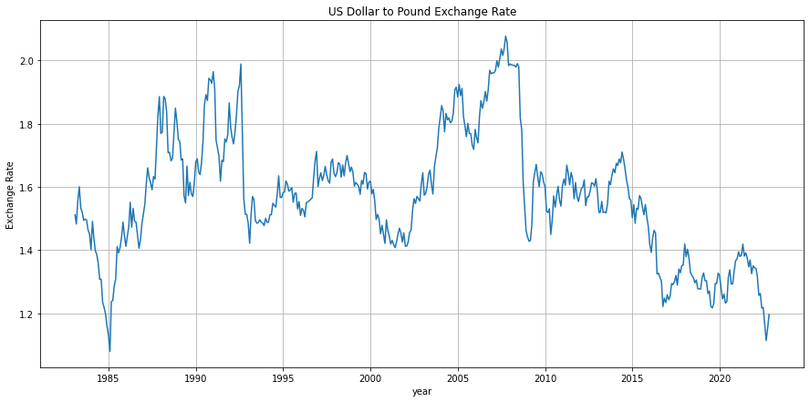

```python
## Plot the Exchange Rate
plt.figure(figsize = (15, 7))
plt.plot(data['DEXUSUK'])
plt.title('US Dollar to Pound Exchange Rate')
plt.ylabel('Exchange Rate')
plt.xlabel('year')
plt.grid()
plt.show()
```

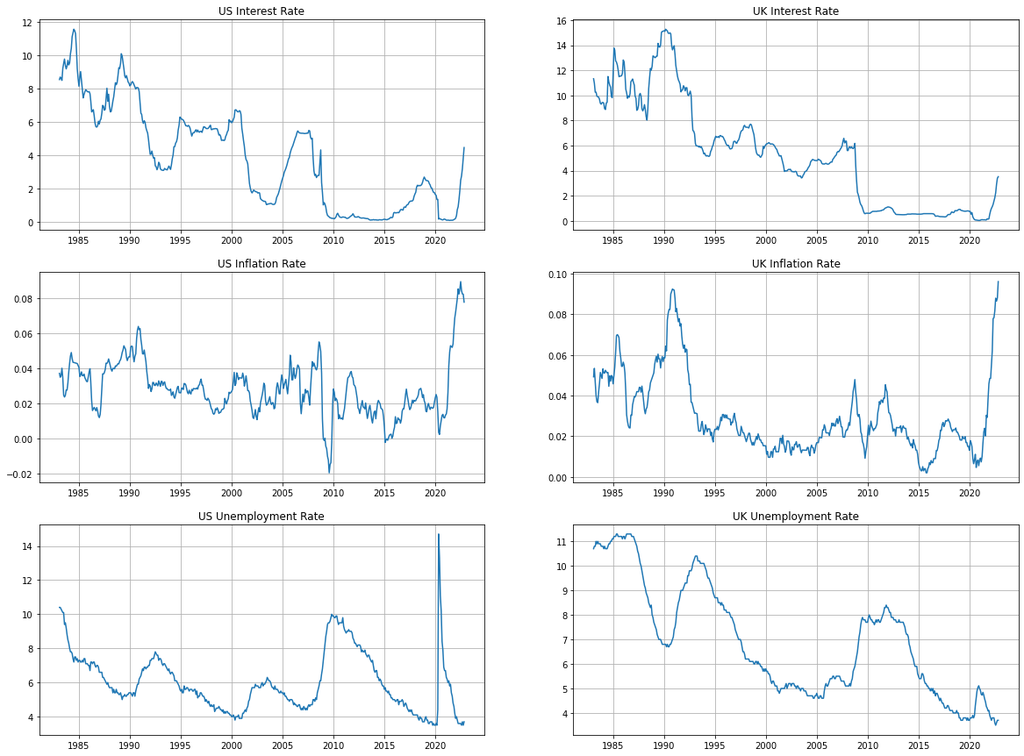

```python
## Plotting the differences
fig, ax = plt.subplots(3, 2, figsize = (20, 15))

# Interest Rates
ax[0,0].plot(data['United States Interest'])
ax[0,0].set_title('US Interest Rate')
ax[0,0].grid()

ax[0,1].plot(data['United Kingdom Interest'])
ax[0,1].set_title('UK Interest Rate')
ax[0,1].grid()

# Inflation Rates
ax[1,0].plot(data['United States Inflation'])
ax[1,0].set_title('US Inflation Rate')
ax[1,0].grid()

ax[1,1].plot(data['United Kingdom Inflation'])
ax[1,1].set_title('UK Inflation Rate')
ax[1,1].grid()

# Unemployment Rates
ax[2,0].plot(data['United States Unemployment'])
ax[2,0].set_title('US Unemployment Rate')
ax[2,0].grid()

ax[2,1].plot(data['United Kingdom Unemployment'])
ax[2,1].set_title('UK Unemployment Rate')
ax[2,1].grid()

plt.show()
```

```python
## Scale the Data:
    # We want the data to be comparable & on the same scale
def scale(X):
    num = X - X.min()
    denom = X.max() - X.min()
    return num/denom

scaled_data = pd.DataFrame(index = data.index)
scaled_data['US_ir'] = scale(data['United States Interest'])
scaled_data['UK_ir'] = scale(data['United Kingdom Interest'])


scaled_data['US_inf'] = scale(data['United States Inflation'])
scaled_data['UK_inf'] = scale(data['United Kingdom Inflation'])

scaled_data['US_unemp'] = scale(data['United States Unemployment'])
scaled_data['UK_unemp'] = scale(data['United Kingdom Unemployment'])

scaled_data['DEXUSUK'] = data['DEXUSUK']
scaled_data['rfr'] = data['rfr']
scaled_data.head()
```

|  | US_ir | UK_ir | US_inf | UK_inf | US_unemp | UK_unemp | DEXUSUK | rfr |
| --- | --- | --- | --- | --- | --- | --- | --- | --- |
| 1983-02-01 | 0.736704 | 0.740946 | 0.520246 | 0.502131 | 0.616071 | 0.923077 | 1.5115 | 0.007153 |
| 1983-03-01 | 0.749782 | 0.717473 | 0.499777 | 0.546416 | 0.616071 | 0.935897 | 1.4825 | 0.006883 |
| 1983-04-01 | 0.744551 | 0.670665 | 0.509473 | 0.470334 | 0.607143 | 0.935897 | 1.5573 | 0.007469 |
| 1983-05-01 | 0.732345 | 0.670514 | 0.547090 | 0.404152 | 0.598214 | 0.961538 | 1.6005 | 0.007015 |
| 1983-06-01 | 0.794246 | 0.649480 | 0.495774 | 0.371417 | 0.589286 | 0.948718 | 1.5330 | 0.007507 |

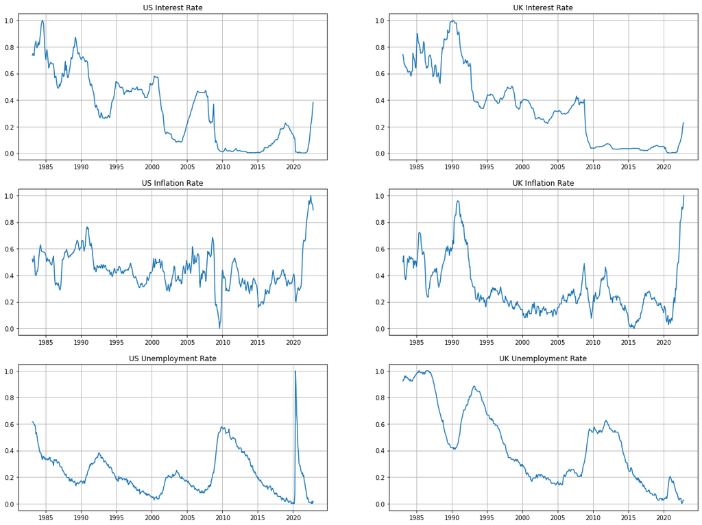

```python
## Plotting the Scaled Data
fig, ax = plt.subplots(3, 2, figsize = (20, 15))

# Interest Rates
ax[0,0].plot(scaled_data['US_ir'])
ax[0,0].set_title('US Interest Rate')
ax[0,0].grid()

ax[0,1].plot(scaled_data['UK_ir'])
ax[0,1].set_title('UK Interest Rate')
ax[0,1].grid()

# Inflation Rates
ax[1,0].plot(scaled_data['US_inf'])
ax[1,0].set_title('US Inflation Rate')
ax[1,0].grid()

ax[1,1].plot(scaled_data['UK_inf'])
ax[1,1].set_title('UK Inflation Rate')
ax[1,1].grid()

# Unemployment Rates
ax[2,0].plot(scaled_data['US_unemp'])
ax[2,0].set_title('US Unemployment Rate')
ax[2,0].grid()

ax[2,1].plot(scaled_data['UK_unemp'])
ax[2,1].set_title('UK Unemployment Rate')
ax[2,1].grid()

plt.show()
```

```python
## Calculating the Differentials using Scaled Data:
    # US - UK

diffs = pd.DataFrame(index = scaled_data.index)

# Interest Rate Differential
ir_diff = scaled_data['US_ir'] - scaled_data['UK_ir']
diffs['ir_diff'] = ir_diff

# Inflation Differential
inf_diff = scaled_data['US_inf'] - scaled_data['UK_inf']
diffs['inf_diff'] = inf_diff

# Unemploymet Differential
unemp_diff = scaled_data['US_unemp'] - scaled_data['UK_unemp']
diffs['unemp_diff'] = unemp_diff


diffs['USUK'] = scaled_data['DEXUSUK']
diffs['rfr'] = scaled_data['rfr']

diffs.head()
```

|  | ir_diff | inf_diff | unemp_diff | USUK | rfr |
| --- | --- | --- | --- | --- | --- |
| 1983-02-01 | -0.004242 | 0.018115 | -0.307005 | 1.5115 | 0.007153 |
| 1983-03-01 | 0.032309 | -0.046639 | -0.319826 | 1.4825 | 0.006883 |
| 1983-04-01 | 0.073886 | 0.039138 | -0.328755 | 1.5573 | 0.007469 |
| 1983-05-01 | 0.061831 | 0.142938 | -0.363324 | 1.6005 | 0.007015 |
| 1983-06-01 | 0.144766 | 0.124357 | -0.359432 | 1.5330 | 0.007507 |

### **Outline Trading Rules based on these forecasts:**

- Long/short positions
- exiting positions

*Kalman Filter:*

- Hyperparameters:
  - **z**: standard deviations
  - **k**: the gain
  - **w**: number of lags
  - **h**: holding period

## **Interest Rate Differential**

### **Optimize at least 2 strategy Hyperparameters:**

- length of holding period
- model hyperparameters (alpha for lasso, number of lags to include, rolling window size, etc)

```python
diffs["returns"] = np.log(diffs["USUK"]).diff()
```

```python
from sklearn.model_selection import train_test_split
# Split the data into training and test sets
train_diffs, test_diffs = train_test_split(diffs, test_size=0.2, shuffle=False, random_state=42)
```

```python
# specify candidate values for hyperparameters
ks = np.linspace(0.1, .99, 10)
zs = np.linspace(0.1, 3, 7)
ws = np.arange(1, 24, 3)
hs = np.arange(1, 12, 1) ## Because we have monthly data, our holding period is in terms of months

import itertools as it
# build a grid with all possible hyperparameters
grid = np.array(np.meshgrid(ks,zs,ws,hs)).T.reshape(-1,4)
```

```python
storage = pd.DataFrame(columns = ["k", "z", "w", "h", "profits"])

for n in range(len(grid)):
    # Each loop we pull out the values for a new set of hyperparamters from the grid
    k,z,w,h= grid[n]

    # We fit a filter and CI using the next set of parameters
    train_diffs["Filter"] = train_diffs["ir_diff"].ewm(alpha = k, adjust = False).mean()
    train_diffs["Filter Error"] = train_diffs["ir_diff"] -train_diffs["Filter"]
    train_diffs["std"] = train_diffs["Filter Error"].rolling(int(w)).std()
    train_diffs["Upper"] = train_diffs["Filter"] + z*train_diffs["std"]
    train_diffs["Lower"] = train_diffs["Filter"] - z*train_diffs["std"]
    train_diffs["test"] = np.where(train_diffs["Filter Error"].abs()>z*train_diffs["std"], 1, 0)*np.sign(train_diffs["Filter Error"])

    # create vectors where we can store information on signals and when the change is first signalled
    train_diffs["test2"] = 0
    train_diffs["signal"] = 0

    for j in train_diffs.index:
        # if there is a change in the signal, we want to take a position for teh next h periods
        if (train_diffs.loc[j, "test"] == 1) &  (train_diffs.shift().loc[j, "test"] != 1):
            train_diffs.loc[j:j+datetime.timedelta(h), "signal"] = 1
            train_diffs.loc[j, "test2"] = 1
        elif (train_diffs.loc[j, "test"] == -1) &  (train_diffs.shift().loc[j, "test"] != -1):
            train_diffs.loc[j:j+datetime.timedelta(h), "signal"] =  -1
            train_diffs.loc[j, "test2"] = -1

# calculate metric
    train_diffs["cumulative_returns"] = (np.exp((train_diffs["signal"].shift()*train_diffs.returns).cumsum())-1)*100

    # store the results
    storage = storage.append({"k":k, "z":z, "w":w, "h":h ,"profits":train_diffs["cumulative_returns"][-1]}, ignore_index = True)
    #print so I can track progress of loop (can take a few minutes)
    #print(n)
```

[output not shown]

```python
# Sorting the Storage DataFrame
storage = storage.sort_values(by = "profits").reset_index(drop = True)
storage.tail(5)
```

|  | k | z | w | h | profits |
| --- | --- | --- | --- | --- | --- |
| 69 | 0.396667 | 0.100000 | 1.0 | 1.0 | 0.000000 |
| 70 | 0.297778 | 3.000000 | 1.0 | 1.0 | 0.000000 |
| 71 | 0.297778 | 2.516667 | 1.0 | 1.0 | 0.000000 |
| 72 | 0.594444 | 0.100000 | 1.0 | 1.0 | 0.000000 |
| 73 | 0.100000 | 1.550000 | 4.0 | 1.0 | 22.137641 |

### **Visualize Optimization process using a heatmap**

```python
# Heatmaps

def heatmap(x, y, metric, values):

    # specify the columns I will be pulling from the results
    p2p = values[[x, y, metric]]

    # If p > 2, we need to group
    heat = np.round(p2p.groupby([x,y]).max(),1)
    heat = heat.unstack()[metric]

    # round labels
    heat.index = np.round(heat.index,2)
    heat.columns = np.round(heat.columns,2)

    # make plot
    f, ax = plt.subplots(figsize=(15, 8))
    ax = sns.heatmap(heat, fmt='.1g')
    ax.set_title("Heat map of "+ metric,size = 15)
    ax.tick_params(axis='both', which='major', labelsize=10)
    ax.set_xlabel(y, size = 15)
    ax.set_ylabel(x, size = 15)
    ax.collections[0].colorbar.set_label(metric, size = 15)
    sns.set(font_scale=1)
    plt.show()
```

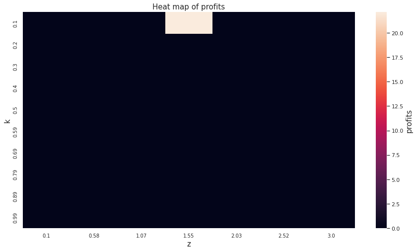

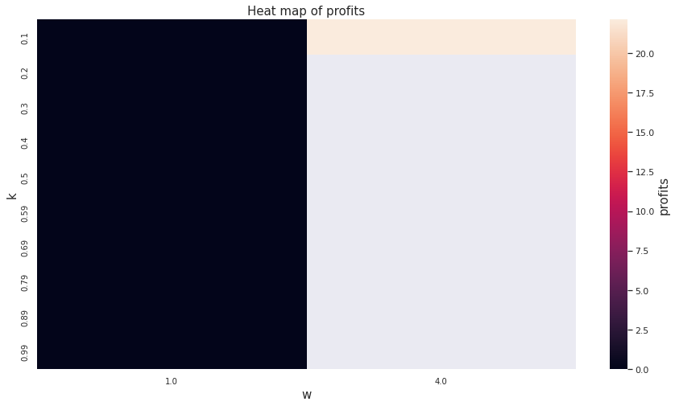

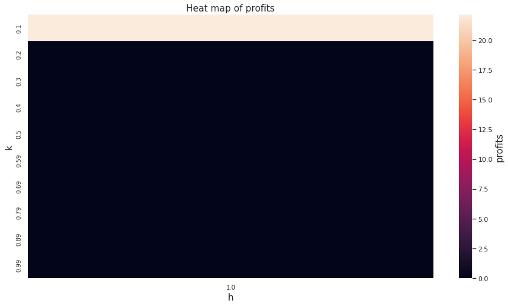

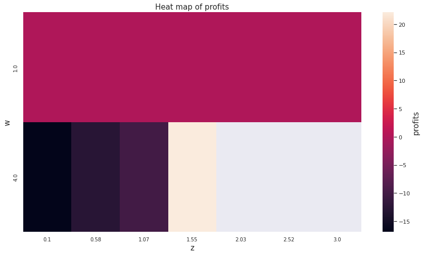

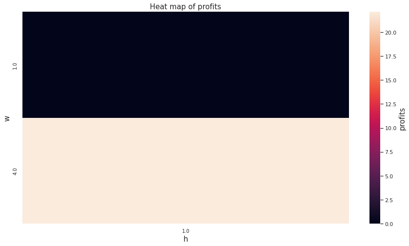

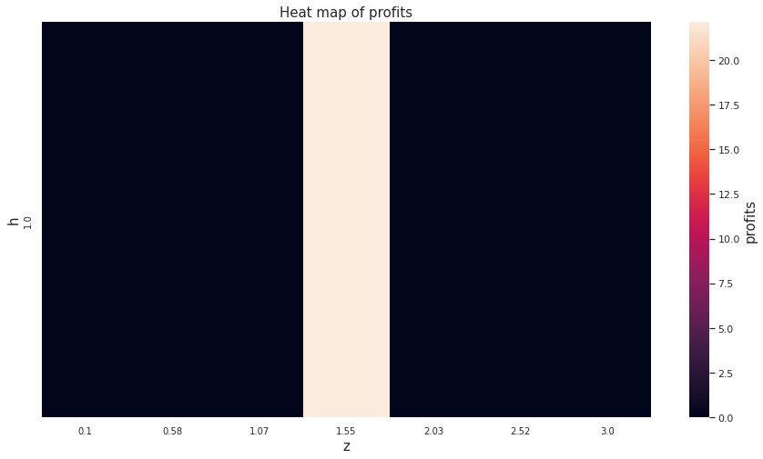

```python
# Heatmap for Hyperparameters
heatmap("k", "z", "profits", storage)
heatmap("k", "w", "profits", storage)
heatmap("k", "h", "profits", storage)

heatmap("w", "z", "profits", storage)
heatmap("w", "h", "profits", storage)

heatmap("h", "z", "profits", storage)
```

### **Trading Strategy: using the optimal results**

```python
# According to the tables, the set of hyper-parameters that
    # produce the largest profits are:
print(blue('Final Hyper-Parameters:', ['bold']))
k, z, w, h, profits = storage.iloc[-1]
print('k:', k)
print('z:', z)
print('w:', w)
print('h:', h)
print('Profits:', profits)
```

```
Final Hyper-Parameters:
k: 0.1
z: 1.55
w: 4.0
h: 1.0
Profits: 22.13764099704967
```

```python
## Implementing the Strategy with the Optimal Results
### Apply the Strategy to the final 20% of the dataset:
ir_strategy = test_diffs.copy()


# Applying the Strategy
ir_strategy["Filter"] = ir_strategy["ir_diff"].ewm(alpha = k, adjust = False).mean()
ir_strategy["Filter Error"] = ir_strategy["ir_diff"] -ir_strategy["Filter"]
ir_strategy["std"] = ir_strategy["Filter Error"].rolling(int(w)).std()
ir_strategy["Upper"] = ir_strategy["Filter"] + z*ir_strategy["std"]
ir_strategy["Lower"] = ir_strategy["Filter"] - z*ir_strategy["std"]

ir_strategy["test"] = np.where(ir_strategy["Filter Error"].abs()>z*ir_strategy["std"],
                             1, 0)*np.sign(ir_strategy["Filter Error"])

ir_strategy["test2"] = 0
ir_strategy["signal"] = 0
for j in ir_strategy.index:
    if (ir_strategy.loc[j, "test"] == 1)&(ir_strategy.shift().loc[j,"test"] != 1):
        ir_strategy.loc[j:j+datetime.timedelta(h), "signal"] = 1
        ir_strategy.loc[j, "test2"] = 1
    elif (ir_strategy.loc[j, "test"] == -1)&(ir_strategy.shift().loc[j, "test"] != -1):
        ir_strategy.loc[j:j+datetime.timedelta(h), "signal"] =  -1
        ir_strategy.loc[j, "test2"] = -1


cum_return_exp = (ir_strategy["signal"].shift()*ir_strategy.returns).cumsum()

ir_strategy["cumulative_returns"]=np.exp(cum_return_exp)-1
ir_strategy["strat_returns"] = ir_strategy["signal"].shift()*ir_strategy.returns
```

### **Produce Equity Curve over a backtest**

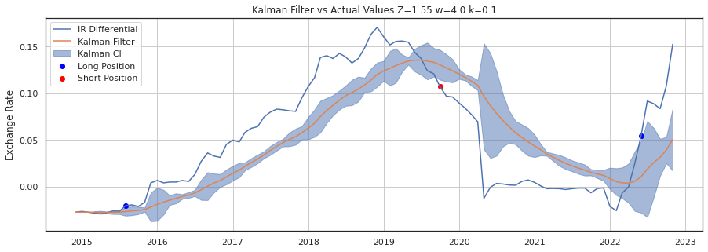

```python
# Visulizing the PE, the Kalman CI, Long & Short Positions
sns.set_style("white")
fig, ax = plt.subplots(figsize = (15, 5))
ax.set_title("Kalman Filter vs Actual Values " +
             "Z="+str(z) + " w=" + str(w)+ " k=" + str(k))

ax.set_ylabel("Exchange Rate")
ax.plot(ir_strategy["ir_diff"])
ax.plot(ir_strategy["Filter"])


ax.fill_between(ir_strategy.index, ir_strategy.Lower,
                ir_strategy.Upper, color='b', alpha=.5)
ax.scatter(ir_strategy[ir_strategy.test2 == 1].index,
           ir_strategy[ir_strategy.test2 == 1]["ir_diff"], color = "blue")
ax.scatter(ir_strategy[ir_strategy.test2 == -1].index,
           ir_strategy[ir_strategy.test2 == -1]["ir_diff"], color = "red")

#ax.axvline(df_copy.index[-5], color = "red", linestyle = '--')
ax.legend(["IR Differential", "Kalman Filter", 'Kalman CI',
           "Long Position", "Short Position"])


#plt.xlim([datetime.date(2000, 1, 1), datetime.date(2004, 1, 1)])
ax.grid()
```

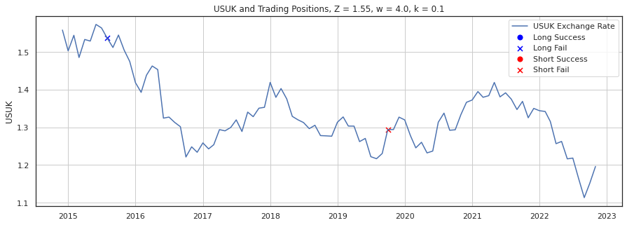

```python
### Plotting the Trading Positions

# Creating Success
success = ((ir_strategy[ir_strategy.test2 != 0]["cumulative_returns"].diff()>0)*1)
ir_strategy["success"] = success.shift(-1)


# Plot
plt.figure(figsize = (15, 5))

plt.title("USUK and Trading Positions"+ ", Z = "
          +str(z) + ", w = " + str(w)+ ", k = " + str(k))
plt.ylabel("USUK")
plt.plot(ir_strategy["USUK"])

longsuccess = ir_strategy[(ir_strategy["success"] == 1) & (ir_strategy["test2"] == 1)]
longfail = ir_strategy[(ir_strategy["success"] == 0) & (ir_strategy["test2"] == 1)]
shortsuccess = ir_strategy[(ir_strategy["success"] == 1) & (ir_strategy["test2"] == -1)]
shortfail = ir_strategy[(ir_strategy["success"] == 0) & (ir_strategy["test2"] == -1)]

plt.scatter(longsuccess.index, longsuccess["USUK"],
            color = 'blue', s = 50)
plt.scatter(longfail.index, longfail["USUK"],
            color = 'blue', s = 50, marker = "x")

plt.scatter(shortsuccess.index, shortsuccess["USUK"],
            color = 'red', s = 50)
plt.scatter(shortfail.index, shortfail["USUK"],
            color = 'red', s = 50, marker = "x")

plt.legend(["USUK Exchange Rate", "Long Success", "Long Fail",
            "Short Success", "Short Fail"])
plt.grid()
```

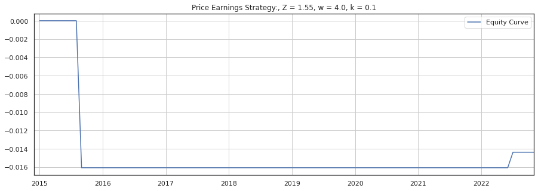

```python
## Plotting the Equity Curve
plt.figure(figsize = (15, 5))
sns.set_style("white")
(ir_strategy["cumulative_returns"]).plot()

plt.title("Price Earnings Strategy:"+ ", Z = "
          +str(z) + ", w = " + str(w)+ ", k = " + str(k))



plt.legend(["Equity Curve"])

plt.grid()
```

### **Use the Binomial Test (directional forecast) or the DMW Test (point forecast)**

Kalman Filter would use a Binomial Test!

```python
diffs
```

|  | ir_diff | inf_diff | unemp_diff | USUK | rfr | returns |
| --- | --- | --- | --- | --- | --- | --- |
| 1983-02-01 | -0.004242 | 0.018115 | -0.307005 | 1.5115 | 0.007153 | NaN |
| 1983-03-01 | 0.032309 | -0.046639 | -0.319826 | 1.4825 | 0.006883 | -0.019373 |
| 1983-04-01 | 0.073886 | 0.039138 | -0.328755 | 1.5573 | 0.007469 | 0.049224 |
| 1983-05-01 | 0.061831 | 0.142938 | -0.363324 | 1.6005 | 0.007015 | 0.027363 |
| 1983-06-01 | 0.144766 | 0.124357 | -0.359432 | 1.5330 | 0.007507 | -0.043089 |
| ... | ... | ... | ... | ... | ... | ... |
| 2022-07-01 | 0.091471 | 0.153336 | -0.003892 | 1.2183 | 0.002296 | 0.001725 |
| 2022-08-01 | 0.088575 | 0.038851 | 0.000000 | 1.1647 | 0.002450 | -0.044993 |
| 2022-09-01 | 0.083235 | 0.037104 | 0.005037 | 1.1134 | 0.002879 | -0.045045 |
| 2022-10-01 | 0.107569 | 0.019505 | -0.025641 | 1.1515 | 0.003314 | 0.033647 |
| 2022-11-01 | 0.152230 | -0.107466 | -0.007784 | 1.1962 | 0.003875 | 0.038084 |

478 rows × 6 columns

```python
## First Create a Daily Dataframe for our strategy:

## Creating Daily Strategy:
drange = pd.date_range(start = ir_strategy.index[0], end = '12/01/2022')
daily_strat = pd.DataFrame(index = drange)


# Integrate the monthly data into the daily data
daily_strat['test'] = ir_strategy['test']
daily_strat['Upper'] = ir_strategy['Upper']
daily_strat['Lower'] = ir_strategy['Lower']
daily_strat['Filter'] = ir_strategy['Filter']
daily_strat['ir_diff'] = ir_strategy['ir_diff']

# Forward Fill NA values
daily_strat["Upper"] = daily_strat["Upper"].ffill()
daily_strat["Lower"] = daily_strat["Lower"].ffill()
daily_strat["Filter"] = daily_strat["Filter"].ffill()
daily_strat["ir_diff"] = daily_strat["ir_diff"].ffill()

# Fill the remaining NA values with 0's (also populates the signals column)
daily_strat = daily_strat.fillna(0)


#### Creating the trading strategy

# Holding Period be 1 month - 30 days
i = 30*h

# Create a column that will populate with daily position
daily_strat.loc[:, 'signal'] = 0

# loop through each day
for j in daily_strat.index:
    # If monthly signal is not 0
    if daily_strat.loc[j, 'test'] !=0:
        # make the next i days equal to the monthly signal
        daily_strat.loc[j:j+datetime.timedelta(i),
                  'signal'] = daily_strat.loc[j, 'test']

# Adding info to the Data
daily_strat['USUK'] = ir_strategy['USUK']
daily_strat['USUK'] = daily_strat['USUK'].ffill()
daily_strat['Returns'] = np.log(daily_strat['USUK']).diff()

# Calculate the Cumulative returns for the current strategy

daily_strat['returns'] = np.exp((daily_strat['signal'].shift()*daily_strat.Returns).cumsum()) - 1
daily_strat
```

|  | test | Upper | Lower | Filter | ir_diff | signal | USUK | Returns | returns |
| --- | --- | --- | --- | --- | --- | --- | --- | --- | --- |
| 2014-12-01 | 0.0 | 0.00000 | 0.000000 | -0.027543 | -0.027543 | 0 | 1.5578 | NaN | NaN |
| 2014-12-02 | 0.0 | 0.00000 | 0.000000 | -0.027543 | -0.027543 | 0 | 1.5578 | 0.0 | 0.000000 |
| 2014-12-03 | 0.0 | 0.00000 | 0.000000 | -0.027543 | -0.027543 | 0 | 1.5578 | 0.0 | 0.000000 |
| 2014-12-04 | 0.0 | 0.00000 | 0.000000 | -0.027543 | -0.027543 | 0 | 1.5578 | 0.0 | 0.000000 |
| 2014-12-05 | 0.0 | 0.00000 | 0.000000 | -0.027543 | -0.027543 | 0 | 1.5578 | 0.0 | 0.000000 |
| ... | ... | ... | ... | ... | ... | ... | ... | ... | ... |
| 2022-11-27 | 0.0 | 0.08361 | 0.016865 | 0.050237 | 0.152230 | 1 | 1.1962 | 0.0 | -0.199849 |
| 2022-11-28 | 0.0 | 0.08361 | 0.016865 | 0.050237 | 0.152230 | 1 | 1.1962 | 0.0 | -0.199849 |
| 2022-11-29 | 0.0 | 0.08361 | 0.016865 | 0.050237 | 0.152230 | 1 | 1.1962 | 0.0 | -0.199849 |
| 2022-11-30 | 0.0 | 0.08361 | 0.016865 | 0.050237 | 0.152230 | 1 | 1.1962 | 0.0 | -0.199849 |
| 2022-12-01 | 0.0 | 0.08361 | 0.016865 | 0.050237 | 0.152230 | 1 | 1.1962 | 0.0 | -0.199849 |

2923 rows × 9 columns

```python
## Setting up the Binomial Test
start = daily_strat[['USUK', 'signal']].index[0]

df = daily_strat[daily_strat.test != 0][['signal', 'USUK']].copy()
df = df[:-2]
df['D'] = df['signal']

df['s_current'] = daily_strat[daily_strat.index.isin(df.index)]['USUK'].values
df['s_future'] = daily_strat[daily_strat.index.isin(df.index +
                    datetime.timedelta(i))]['USUK'].values

# Get the realized exchange Rate
df['R'] = np.where(df['s_future'] >= df['s_current'], 1, -1)

# Sample Covariances
df['W'] = (df['D'] - np.mean(df['D']))*(df['R'] - np.mean(df['R']))
T_B = np.mean(df['W'])
```

```python
### The Binomial Test

# Calculate LRV estimator
dy = df['W'] - np.mean(df['W'])
gamma_0 = sum((dy)**2)/len(df)
gamma_1 = np.mean((dy*dy.shift(-1))[:len(df) - 1])
LRV = gamma_0 + 2*(1-1/2)*gamma_1

# Creating the Test Statistic & Critical Value
from scipy.stats import norm

statistic = T_B/np.sqrt(LRV/df.shape[0])
cv = round(norm.ppf(0.95), 2)

print('T:', T_B)
print('Test Statistic:', statistic)
print('5% Critical Value:', cv)
```

```
T: -0.09485659349463232
Test Statistic: -1.2930617564262326
5% Critical Value: 1.64
```

```python
### The Weighted Binomial Test
df = df.dropna()

# Weighted Mean
df['W2'] = df['D'] * (df['s_future'] - df['s_current'])
T_WB = np.mean(df['W2'])
print('Weighted T:', T_WB)

# Calculating the LRV Estimator
dy_2 = df['W2'] - np.mean(df['W2'])
gamma_0 = sum((dy_2)**2)/len(df)
gamma_1 = np.mean((dy_2*dy_2.shift(-1))[:len(df) -1])
LRV_2 = gamma_0 + 2*(1-1/2)*gamma_1

# Creating the Test Statistic & Critical Value
statistic_2 = T_WB/np.sqrt(LRV_2/len(df))

print('Test Statistic:', statistic_2)
print('5% Critical Value:', cv)
```

```
Weighted T: -0.0031746835443037906
Test Statistic: -1.4433384198783394
5% Critical Value: 1.64
```

## **Inflation Rate Differential**

### **Optimize at least 2 strategy Hyperparameters:**

- length of holding period
- model hyperparameters (alpha for lasso, number of lags to include, rolling window size, etc)

```python
# specify candidate values for hyperparameters
ks = np.linspace(0.1, .99, 10)
zs = np.linspace(0.1, 3, 7)
ws = np.arange(1, 24, 3)
hs = np.arange(1, 12, 1)

import itertools as it
# build a grid with all possible hyperparameters
grid = np.array(np.meshgrid(ks,zs,ws,hs)).T.reshape(-1,4)
```

```python
storage = pd.DataFrame(columns = ["k", "z", "w", "h", "profits"])

for n in range(len(grid)):
    # Each loop we pull out the values for a new set of hyperparamters from the grid
    k,z,w,h= grid[n]

    # We fit a filter and CI using the next set of parameters
    train_diffs["Filter"] = train_diffs["inf_diff"].ewm(alpha = k, adjust = False).mean()
    train_diffs["Filter Error"] = train_diffs["inf_diff"] -train_diffs["Filter"]
    train_diffs["std"] = train_diffs["Filter Error"].rolling(int(w)).std()
    train_diffs["Upper"] = train_diffs["Filter"] + z*train_diffs["std"]
    train_diffs["Lower"] = train_diffs["Filter"] - z*train_diffs["std"]
    train_diffs["test"] = np.where(train_diffs["Filter Error"].abs()>z*train_diffs["std"], 1, 0)\
        *np.sign(train_diffs["Filter Error"])

    # create vectors where we can store information on signals and when the change is first signalled
    train_diffs["test2"] = 0
    train_diffs["signal"] = 0

    for j in train_diffs.index:
        # if there is a change in the signal, we want to take a position for teh next h periods
        if (train_diffs.loc[j, "test"] == 1) &  (train_diffs.shift().loc[j, "test"] != 1):
            train_diffs.loc[j:j+datetime.timedelta(h), "signal"] = 1
            train_diffs.loc[j, "test2"] = 1
        elif (train_diffs.loc[j, "test"] == -1) &  (train_diffs.shift().loc[j, "test"] != -1):
            train_diffs.loc[j:j+datetime.timedelta(h), "signal"] =  -1
            train_diffs.loc[j, "test2"] = -1

# calculate metric
    train_diffs["cumulative_returns"] = (np.exp((train_diffs["signal"].shift()*train_diffs.returns).cumsum())-1)*100

    # store the results
    storage = storage.append({"k":k, "z":z, "w":w, "h":h ,"profits":train_diffs["cumulative_returns"][-1]}, ignore_index = True)
    #print so I can track progress of loop (can take a few minutes)
    #print(n)
```

[output not shown]

```python
# Sorting the Storage DataFrame
storage = storage.sort_values(by = "profits").reset_index(drop = True)
storage.tail()
```

|  | k | z | w | h | profits |
| --- | --- | --- | --- | --- | --- |
| 70 | 0.396667 | 0.100000 | 1.0 | 1.0 | 0.000000 |
| 71 | 0.297778 | 3.000000 | 1.0 | 1.0 | 0.000000 |
| 72 | 0.396667 | 3.000000 | 1.0 | 1.0 | 0.000000 |
| 73 | 0.100000 | 0.583333 | 4.0 | 1.0 | 1.903780 |
| 74 | 0.100000 | 2.033333 | 4.0 | 1.0 | 2.543308 |

### **Visualize Optimization process using a heatmap**

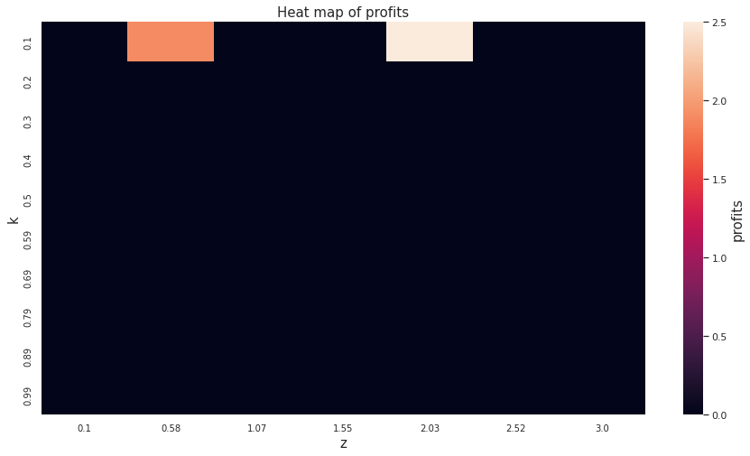

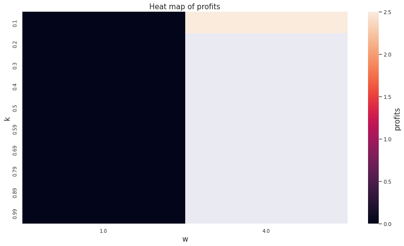

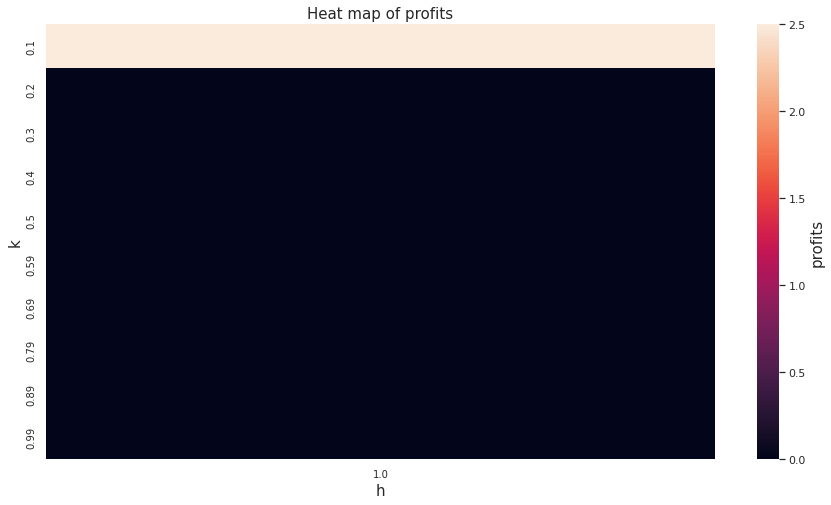

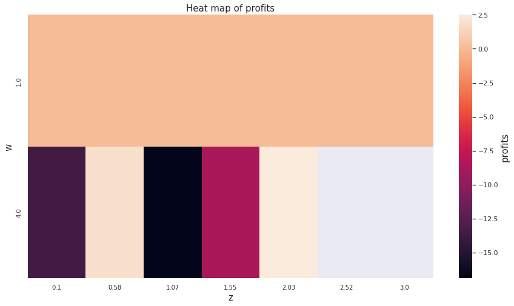

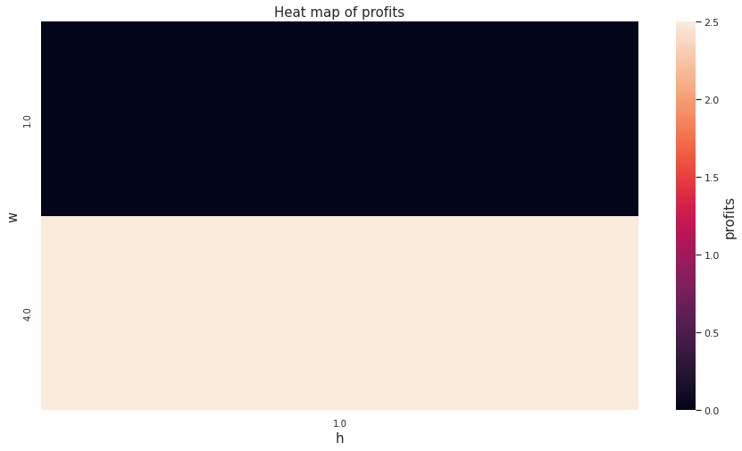

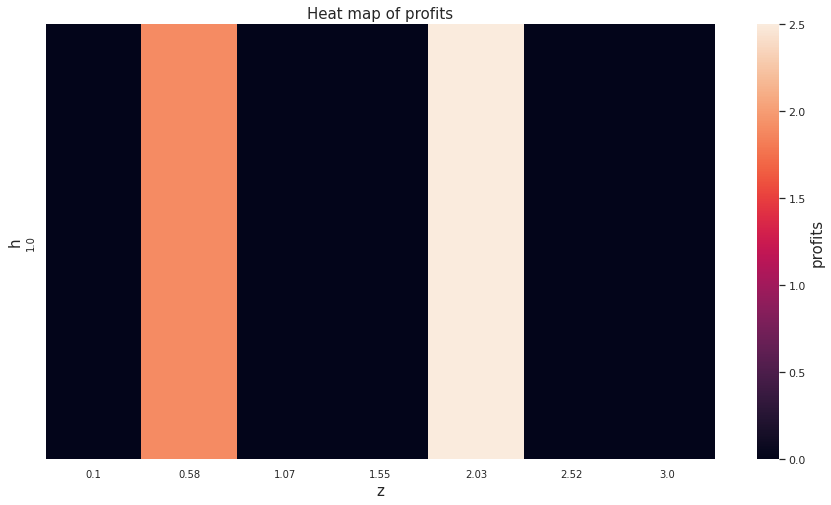

```python
# Heatmap for Hyperparameters
heatmap("k", "z", "profits", storage)
heatmap("k", "w", "profits", storage)
heatmap("k", "h", "profits", storage)

heatmap("w", "z", "profits", storage)
heatmap("w", "h", "profits", storage)

heatmap("h", "z", "profits", storage)
```

### **Trading Strategy: using the optimal results**

```python
# According to the tables, the set of hyper-parameters that
    # produce the largest profits are:
print(blue('Final Hyper-Parameters:', ['bold']))
k, z, w, h, p = storage.iloc[-1]
print('k:', k)
print('z:', z)
print('w:', w)
print('h:', h)
print('Profits:', p)
```

```
Final Hyper-Parameters:
k: 0.1
z: 2.033333333333333
w: 4.0
h: 1.0
Profits: 2.543307840271125
```

```python
## Implementing the Strategy with the Optimal Results
### Apply the Strategy to the final 20% of the dataset:
inf_strategy = test_diffs.copy()


# Applying the Strategy
inf_strategy["Filter"] = inf_strategy["inf_diff"].ewm(alpha = k, adjust = False).mean()
inf_strategy["Filter Error"] = inf_strategy["inf_diff"] -inf_strategy["Filter"]
inf_strategy["std"] = inf_strategy["Filter Error"].rolling(int(w)).std()
inf_strategy["Upper"] = inf_strategy["Filter"] + z*inf_strategy["std"]
inf_strategy["Lower"] = inf_strategy["Filter"] - z*inf_strategy["std"]

inf_strategy["test"] = np.where(inf_strategy["Filter Error"].abs()>z*inf_strategy["std"],
                             1, 0)*np.sign(inf_strategy["Filter Error"])

inf_strategy["test2"] = 0
inf_strategy["signal"] = 0
for j in inf_strategy.index:
    if (inf_strategy.loc[j, "test"] == 1)&(inf_strategy.shift().loc[j,"test"] != 1):
        inf_strategy.loc[j:j+datetime.timedelta(h), "signal"] = 1
        inf_strategy.loc[j, "test2"] = 1
    elif (inf_strategy.loc[j, "test"] == -1)&(inf_strategy.shift().loc[j, "test"] != -1):
        inf_strategy.loc[j:j+datetime.timedelta(h), "signal"] =  -1
        inf_strategy.loc[j, "test2"] = -1


cum_return_exp = (inf_strategy["signal"].shift()*inf_strategy.returns).cumsum()

inf_strategy["cumulative_returns"]=np.exp(cum_return_exp)-1
inf_strategy["strat_returns"] = inf_strategy["signal"].shift()*inf_strategy.returns
```

### **Produce Equity Curve over a backtest**

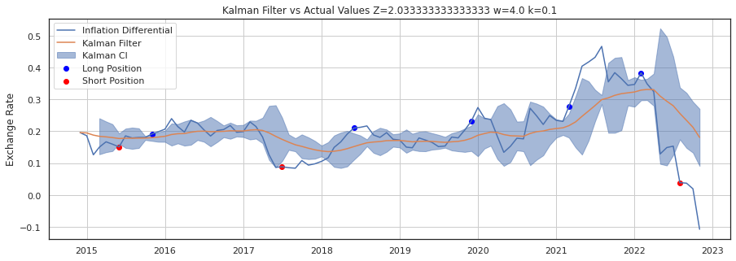

```python
# Visulizing the PE, the Kalman CI, Long & Short Positions
sns.set_style("white")
fig, ax = plt.subplots(figsize = (15, 5))
ax.set_title("Kalman Filter vs Actual Values " +
             "Z="+str(z) + " w=" + str(w)+ " k=" + str(k))

ax.set_ylabel("Exchange Rate")
ax.plot(inf_strategy["inf_diff"])
ax.plot(inf_strategy["Filter"])


ax.fill_between(inf_strategy.index, inf_strategy.Lower,
                inf_strategy.Upper, color='b', alpha=.5)
ax.scatter(inf_strategy[inf_strategy.test2 == 1].index,
           inf_strategy[inf_strategy.test2 == 1]["inf_diff"], color = "blue")
ax.scatter(inf_strategy[inf_strategy.test2 == -1].index,
           inf_strategy[inf_strategy.test2 == -1]["inf_diff"], color = "red")

#ax.axvline(df_copy.index[-5], color = "red", linestyle = '--')
ax.legend(["Inflation Differential", "Kalman Filter", 'Kalman CI',
           "Long Position", "Short Position"])


#plt.xlim([datetime.date(2000, 1, 1), datetime.date(2004, 1, 1)])
ax.grid()
```

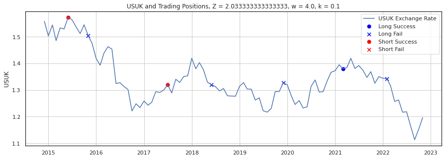

```python
### Plotting the Trading Positions

# Creating Success
success = ((inf_strategy[inf_strategy.test2 != 0]["cumulative_returns"].diff()>0)*1)
inf_strategy["success"] = success.shift(-1)


# Plot
plt.figure(figsize = (15, 5))

plt.title("USUK and Trading Positions"+ ", Z = "
          +str(z) + ", w = " + str(w)+ ", k = " + str(k))
plt.ylabel("USUK")
plt.plot(inf_strategy["USUK"])

longsuccess = inf_strategy[(inf_strategy["success"] == 1) & (inf_strategy["test2"] == 1)]
longfail = inf_strategy[(inf_strategy["success"] == 0) & (inf_strategy["test2"] == 1)]
shortsuccess = inf_strategy[(inf_strategy["success"] == 1) & (inf_strategy["test2"] == -1)]
shortfail = inf_strategy[(inf_strategy["success"] == 0) & (inf_strategy["test2"] == -1)]

plt.scatter(longsuccess.index, longsuccess["USUK"],
            color = 'blue', s = 50)
plt.scatter(longfail.index, longfail["USUK"],
            color = 'blue', s = 50, marker = "x")

plt.scatter(shortsuccess.index, shortsuccess["USUK"],
            color = 'red', s = 50)
plt.scatter(shortfail.index, shortfail["USUK"],
            color = 'red', s = 50, marker = "x")

plt.legend(["USUK Exchange Rate", "Long Success", "Long Fail",
            "Short Success", "Short Fail"])
plt.grid()
```

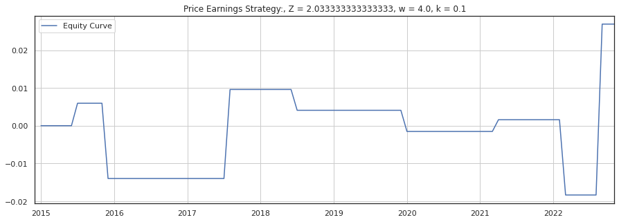

```python
## Plotting the Equity Curve
plt.figure(figsize = (15, 5))
sns.set_style("white")
(inf_strategy["cumulative_returns"]).plot()

plt.title("Price Earnings Strategy:"+ ", Z = "
          +str(z) + ", w = " + str(w)+ ", k = " + str(k))


plt.legend(["Equity Curve"])

plt.grid()
```

### **Use the Binomial Test (directional forecast) or the DMW Test (point forecast)**

Kalman Filter would use a Binomial Test!

```python
## First Create a Daily Dataframe for our strategy:

## Creating Daily Strategy:
drange = pd.date_range(start = inf_strategy.index[0], end = '12/01/2022')
daily_strat = pd.DataFrame(index = drange)


# Integrate the monthly data into the daily data
daily_strat['test'] = inf_strategy['test']
daily_strat['Upper'] = inf_strategy['Upper']
daily_strat['Lower'] = inf_strategy['Lower']
daily_strat['Filter'] = inf_strategy['Filter']
daily_strat['inf_diff'] = inf_strategy['inf_diff']

# Forward Fill NA values
daily_strat["Upper"] = daily_strat["Upper"].ffill()
daily_strat["Lower"] = daily_strat["Lower"].ffill()
daily_strat["Filter"] = daily_strat["Filter"].ffill()
daily_strat["inf_diff"] = daily_strat["inf_diff"].ffill()

# Fill the remaining NA values with 0's (also populates the signals column)
daily_strat = daily_strat.fillna(0)


#### Creating the trading strategy

# Holding Period be 1 month - 30 days
i = 30*h

# Create a column that will populate with daily position
daily_strat.loc[:, 'signal'] = 0

# loop through each day
for j in daily_strat.index:
    # If monthly signal is not 0
    if daily_strat.loc[j, 'test'] !=0:
        # make the next i days equal to the monthly signal
        daily_strat.loc[j:j+datetime.timedelta(i),
                  'signal'] = daily_strat.loc[j, 'test']

# Adding info to the Data
daily_strat['USUK'] = inf_strategy['USUK']
daily_strat['USUK'] = daily_strat['USUK'].ffill()
daily_strat['Returns'] = np.log(daily_strat['USUK']).diff()

# Calculate the Cumulative returns for the current strategy

daily_strat['returns'] = np.exp((daily_strat['signal'].shift()*daily_strat.Returns).cumsum()) - 1
daily_strat
```

|  | test | Upper | Lower | Filter | inf_diff | signal | USUK | Returns | returns |
| --- | --- | --- | --- | --- | --- | --- | --- | --- | --- |
| 2014-12-01 | 0.0 | 0.000000 | 0.000000 | 0.195847 | 0.195847 | 0 | 1.5578 | NaN | NaN |
| 2014-12-02 | 0.0 | 0.000000 | 0.000000 | 0.195847 | 0.195847 | 0 | 1.5578 | 0.0 | 0.000000 |
| 2014-12-03 | 0.0 | 0.000000 | 0.000000 | 0.195847 | 0.195847 | 0 | 1.5578 | 0.0 | 0.000000 |
| 2014-12-04 | 0.0 | 0.000000 | 0.000000 | 0.195847 | 0.195847 | 0 | 1.5578 | 0.0 | 0.000000 |
| 2014-12-05 | 0.0 | 0.000000 | 0.000000 | 0.195847 | 0.195847 | 0 | 1.5578 | 0.0 | 0.000000 |
| ... | ... | ... | ... | ... | ... | ... | ... | ... | ... |
| 2022-11-27 | 0.0 | 0.270325 | 0.090946 | 0.180636 | -0.107466 | -1 | 1.1962 | 0.0 | -0.204231 |
| 2022-11-28 | 0.0 | 0.270325 | 0.090946 | 0.180636 | -0.107466 | -1 | 1.1962 | 0.0 | -0.204231 |
| 2022-11-29 | 0.0 | 0.270325 | 0.090946 | 0.180636 | -0.107466 | -1 | 1.1962 | 0.0 | -0.204231 |
| 2022-11-30 | 0.0 | 0.270325 | 0.090946 | 0.180636 | -0.107466 | -1 | 1.1962 | 0.0 | -0.204231 |
| 2022-12-01 | 0.0 | 0.270325 | 0.090946 | 0.180636 | -0.107466 | -1 | 1.1962 | 0.0 | -0.204231 |

2923 rows × 9 columns

```python
## Setting up the Binomial Test
start = daily_strat[['USUK', 'signal']].index[0]

df = daily_strat[daily_strat.test != 0][['signal', 'USUK']].copy()
df = df[:-2]
df['D'] = df['signal']

df['s_current'] = daily_strat[daily_strat.index.isin(df.index)]['USUK'].values
df['s_future'] = daily_strat[daily_strat.index.isin(df.index +
                    datetime.timedelta(i))]['USUK'].values

# Get the realized exchange Rate
df['R'] = np.where(df['s_future'] >= df['s_current'], 1, -1)

# Sample Covariances
df['W'] = (df['D'] - np.mean(df['D']))*(df['R'] - np.mean(df['R']))
T_B = np.mean(df['W'])
```

```python
### The Binomial Test

# Calculate LRV estimator
dy = df['W'] - np.mean(df['W'])
gamma_0 = sum((dy)**2)/len(df)
gamma_1 = np.mean((dy*dy.shift(-1))[:len(df) - 1])
LRV = gamma_0 + 2*(1-1/2)*gamma_1

# Creating the Test Statistic & Critical Value
from scipy.stats import norm

statistic = T_B/np.sqrt(LRV/df.shape[0])
cv = round(norm.ppf(0.95), 2)

print('T:', T_B)
print('Test Statistic:', statistic)
print('5% Critical Value:', cv)
```

```
T: -0.03292181069958845
Test Statistic: -0.2367160382369996
5% Critical Value: 1.64
```

```python
### The Weighted Binomial Test
df = df.dropna()

# Weighted Mean
df['W2'] = df['D'] * (df['s_future'] - df['s_current'])
T_WB = np.mean(df['W2'])
print('Weighted T:', T_WB)

# Calculating the LRV Estimator
dy_2 = df['W2'] - np.mean(df['W2'])
gamma_0 = sum((dy_2)**2)/len(df)
gamma_1 = np.mean((dy_2*dy_2.shift(-1))[:len(df) -1])
LRV_2 = gamma_0 + 2*(1-1/2)*gamma_1

# Creating the Test Statistic & Critical Value
statistic_2 = T_WB/np.sqrt(LRV_2/len(df))

print('Test Statistic:', statistic_2)
print('5% Critical Value:', cv)
```

```
Weighted T: -0.0008851851851851946
Test Statistic: -0.2760322227198131
5% Critical Value: 1.64
```

## **Unemployment Rate Differential**

### **Optimize at least 2 strategy Hyperparameters:**

- length of holding period
- model hyperparameters (alpha for lasso, number of lags to include, rolling window size, etc)

```python
# specify candidate values for hyperparameters
ks = np.linspace(0.1, .99, 10)
zs = np.linspace(0.1, 3, 7)
ws = np.arange(1, 24, 3)
hs = np.arange(1, 12, 1)

import itertools as it
# build a grid with all possible hyperparameters
grid = np.array(np.meshgrid(ks,zs,ws,hs)).T.reshape(-1,4)
```

```python
storage = pd.DataFrame(columns = ["k", "z", "w", "h", "profits"])

for n in range(len(grid)):
    # Each loop we pull out the values for a new set of hyperparamters from the grid
    k,z,w,h= grid[n]

    # We fit a filter and CI using the next set of parameters
    train_diffs["Filter"] = train_diffs["unemp_diff"].ewm(alpha = k, adjust = False).mean()
    train_diffs["Filter Error"] = train_diffs["unemp_diff"] -train_diffs["Filter"]
    train_diffs["std"] = train_diffs["Filter Error"].rolling(int(w)).std()
    train_diffs["Upper"] = train_diffs["Filter"] + z*train_diffs["std"]
    train_diffs["Lower"] = train_diffs["Filter"] - z*train_diffs["std"]
    train_diffs["test"] = np.where(train_diffs["Filter Error"].abs()>z*train_diffs["std"], 1, 0)\
        *np.sign(train_diffs["Filter Error"])

    # create vectors where we can store information on signals and when the change is first signalled
    train_diffs["test2"] = 0
    train_diffs["signal"] = 0

    for j in train_diffs.index:
        # if there is a change in the signal, we want to take a position for the next h periods
        if (train_diffs.loc[j, "test"] == 1) &  (train_diffs.shift().loc[j, "test"] != 1):
            train_diffs.loc[j:j+datetime.timedelta(h), "signal"] = 1
            train_diffs.loc[j, "test2"] = 1
        elif (train_diffs.loc[j, "test"] == -1) &  (train_diffs.shift().loc[j, "test"] != -1):
            train_diffs.loc[j:j+datetime.timedelta(h), "signal"] =  -1
            train_diffs.loc[j, "test2"] = -1

# calculate metric
    train_diffs["cumulative_returns"] = (np.exp((train_diffs["signal"].shift()*train_diffs.returns).cumsum())-1)*100

    # store the results
    storage = storage.append({"k":k, "z":z, "w":w, "h":h ,"profits":train_diffs["cumulative_returns"][-1]}, ignore_index = True)
    #print so I can track progress of loop (can take a few minutes)
    #print(n)
```

[output not shown]

[output cut: 11 more lines]

[output not shown]

```python
# Sorting the Storage DataFrame
storage = storage.sort_values(by = "profits").reset_index(drop = True)
storage.tail()
```

|  | k | z | w | h | profits |
| --- | --- | --- | --- | --- | --- |
| 99 | 0.198889 | 1.066667 | 4.0 | 1.0 | 26.564868 |
| 100 | 0.100000 | 0.100000 | 4.0 | 1.0 | 27.660266 |
| 101 | 0.495556 | 0.583333 | 4.0 | 1.0 | 29.603869 |
| 102 | 0.396667 | 0.583333 | 4.0 | 1.0 | 33.620882 |
| 103 | 0.297778 | 1.066667 | 4.0 | 1.0 | 43.802466 |

### **Visualize Optimization process using a heatmap**

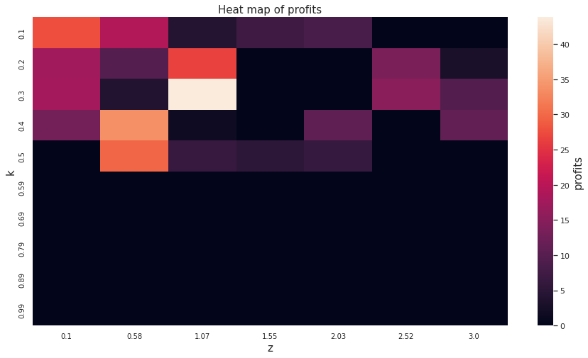

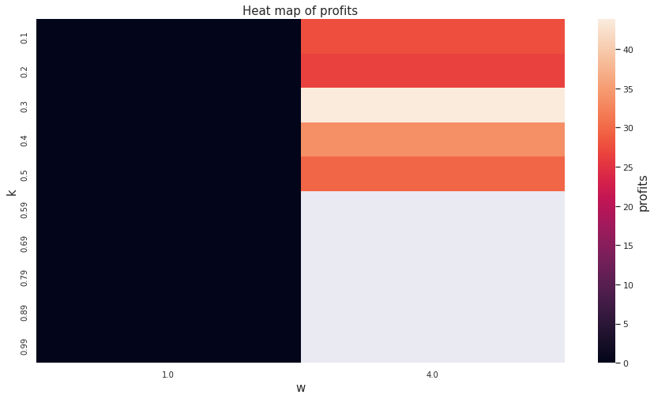

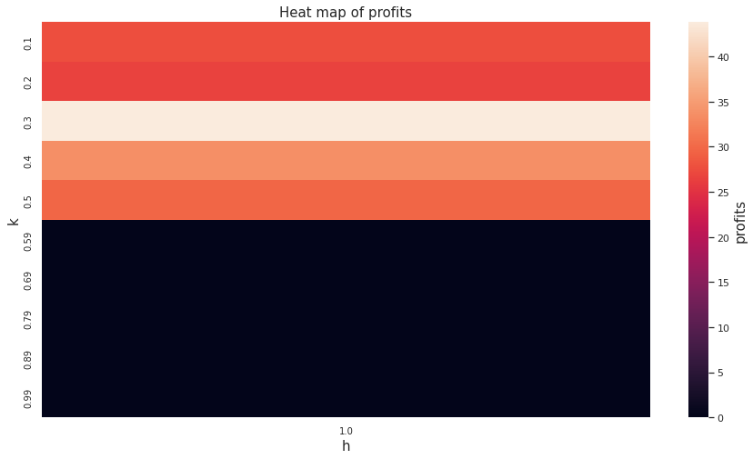

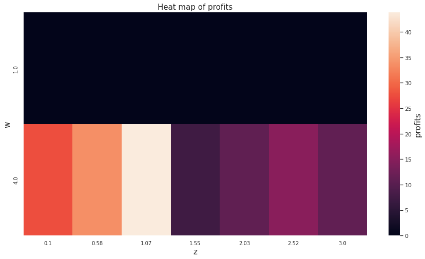

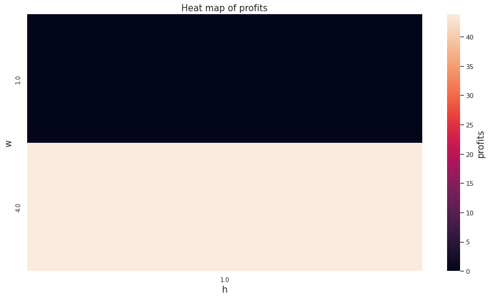

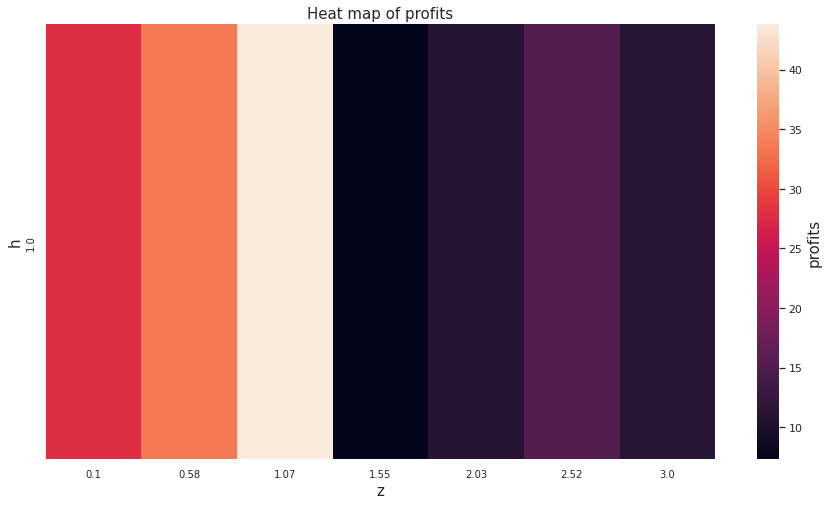

```python
# Heatmap for Hyperparameters
# Heatmap for Hyperparameters
heatmap("k", "z", "profits", storage)
heatmap("k", "w", "profits", storage)
heatmap("k", "h", "profits", storage)

heatmap("w", "z", "profits", storage)
heatmap("w", "h", "profits", storage)

heatmap("h", "z", "profits", storage)
```

### **Trading Strategy: using the optimal results**

```python
# According to the tables, the set of hyper-parameters that
    # produce the largest profits are:
print(blue('Final Hyper-Parameters:', ['bold']))
k, z, w, h, p = storage.iloc[-1]
print('k:', k)
print('z:', z)
print('w:', w)
print('h:', h)
print('Profits:', p)
```

```
Final Hyper-Parameters:
k: 0.2977777777777778
z: 1.0666666666666667
w: 4.0
h: 1.0
Profits: 43.802465732691466
```

```python
## Implementing the Strategy with the Optimal Results
### Apply the Strategy to the final 20% of the dataset:
unemp_strategy = test_diffs.copy()


# Applying the Strategy
unemp_strategy["Filter"] = unemp_strategy["unemp_diff"].ewm(alpha = k, adjust = False).mean()
unemp_strategy["Filter Error"] = unemp_strategy["unemp_diff"] -unemp_strategy["Filter"]
unemp_strategy["std"] = unemp_strategy["Filter Error"].rolling(int(w)).std()
unemp_strategy["Upper"] = unemp_strategy["Filter"] + z*unemp_strategy["std"]
unemp_strategy["Lower"] = unemp_strategy["Filter"] - z*unemp_strategy["std"]

unemp_strategy["test"] = np.where(unemp_strategy["Filter Error"].abs()>z*unemp_strategy["std"],
                             1, 0)*np.sign(unemp_strategy["Filter Error"])

unemp_strategy["test2"] = 0
unemp_strategy["signal"] = 0
for j in unemp_strategy.index:
    if (unemp_strategy.loc[j, "test"] == 1)&(unemp_strategy.shift().loc[j,"test"] != 1):
        unemp_strategy.loc[j:j+datetime.timedelta(h), "signal"] = 1
        unemp_strategy.loc[j, "test2"] = 1
    elif (unemp_strategy.loc[j, "test"] == -1)&(unemp_strategy.shift().loc[j, "test"] != -1):
        unemp_strategy.loc[j:j+datetime.timedelta(h), "signal"] =  -1
        unemp_strategy.loc[j, "test2"] = -1


cum_return_exp = (unemp_strategy["signal"].shift()*unemp_strategy.returns).cumsum()

unemp_strategy["cumulative_returns"]=np.exp(cum_return_exp)-1
unemp_strategy["strat_returns"] = unemp_strategy["signal"].shift()*unemp_strategy.returns
```

### **Produce Equity Curve over a backtest**

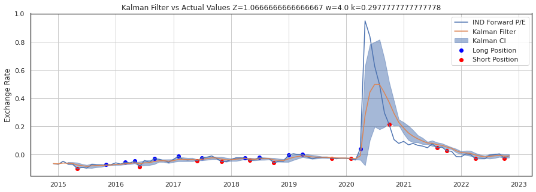

```python
# Visulizing the PE, the Kalman CI, Long & Short Positions
sns.set_style("white")
fig, ax = plt.subplots(figsize = (15, 5))
ax.set_title("Kalman Filter vs Actual Values " +
             "Z="+str(z) + " w=" + str(w)+ " k=" + str(k))

ax.set_ylabel("Exchange Rate")
ax.plot(unemp_strategy["unemp_diff"])
ax.plot(unemp_strategy["Filter"])


ax.fill_between(unemp_strategy.index, unemp_strategy.Lower,
                unemp_strategy.Upper, color='b', alpha=.5)
ax.scatter(unemp_strategy[unemp_strategy.test2 == 1].index,
           unemp_strategy[unemp_strategy.test2 == 1]["unemp_diff"], color = "blue")
ax.scatter(unemp_strategy[unemp_strategy.test2 == -1].index,
           unemp_strategy[unemp_strategy.test2 == -1]["unemp_diff"], color = "red")

#ax.axvline(df_copy.index[-5], color = "red", linestyle = '--')
ax.legend(["IND Forward P/E", "Kalman Filter", 'Kalman CI',
           "Long Position", "Short Position"])


#plt.xlim([datetime.date(2000, 1, 1), datetime.date(2004, 1, 1)])
ax.grid()
```

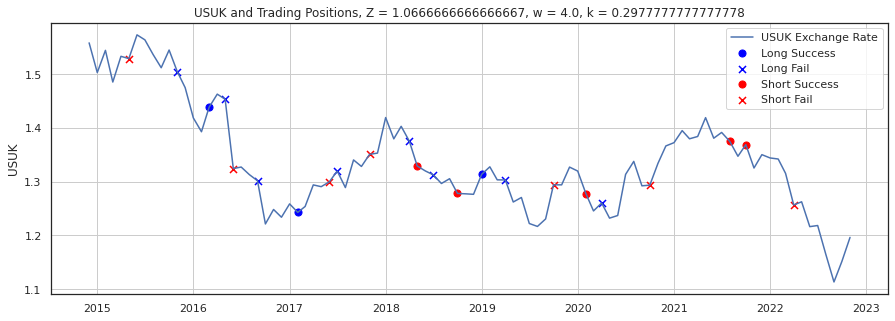

```python
### Plotting the Trading Positions

# Creating Success
success = ((unemp_strategy[unemp_strategy.test2 != 0]["cumulative_returns"].diff()>0)*1)
unemp_strategy["success"] = success.shift(-1)


# Plot
plt.figure(figsize = (15, 5))

plt.title("USUK and Trading Positions"+ ", Z = "
          +str(z) + ", w = " + str(w)+ ", k = " + str(k))
plt.ylabel("USUK")
plt.plot(unemp_strategy["USUK"])

longsuccess = unemp_strategy[(unemp_strategy["success"] == 1) & (unemp_strategy["test2"] == 1)]
longfail = unemp_strategy[(unemp_strategy["success"] == 0) & (unemp_strategy["test2"] == 1)]
shortsuccess = unemp_strategy[(unemp_strategy["success"] == 1) & (unemp_strategy["test2"] == -1)]
shortfail = unemp_strategy[(unemp_strategy["success"] == 0) & (unemp_strategy["test2"] == -1)]

plt.scatter(longsuccess.index, longsuccess["USUK"],
            color = 'blue', s = 50)
plt.scatter(longfail.index, longfail["USUK"],
            color = 'blue', s = 50, marker = "x")

plt.scatter(shortsuccess.index, shortsuccess["USUK"],
            color = 'red', s = 50)
plt.scatter(shortfail.index, shortfail["USUK"],
            color = 'red', s = 50, marker = "x")

plt.legend(["USUK Exchange Rate", "Long Success", "Long Fail",
            "Short Success", "Short Fail"])
plt.grid()
```

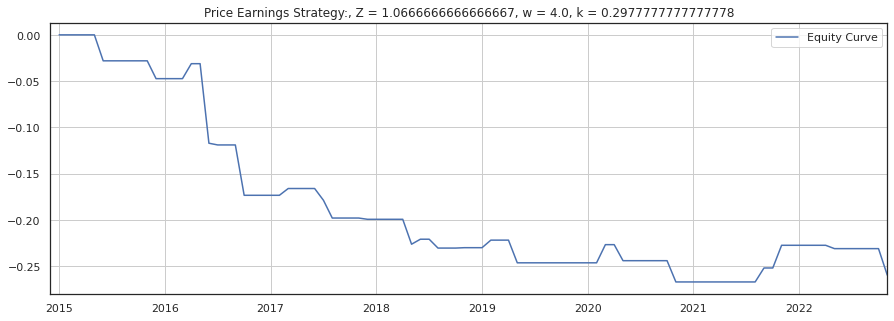

```python
## Plotting the Equity Curve
plt.figure(figsize = (15, 5))
sns.set_style("white")
(unemp_strategy["cumulative_returns"]).plot()

plt.title("Price Earnings Strategy:"+ ", Z = "
          +str(z) + ", w = " + str(w)+ ", k = " + str(k))



plt.legend(["Equity Curve"])

plt.grid()
```

### **Use the Binomial Test (directional forecast) or the DMW Test (point forecast)**

Kalman Filter would use a Binomial Test!

```python
## First Create a Daily Dataframe for our strategy:

## Creating Daily Strategy:
drange = pd.date_range(start = unemp_strategy.index[0], end = '12/01/2022')
daily_strat = pd.DataFrame(index = drange)


# Integrate the monthly data into the daily data
daily_strat['test'] = unemp_strategy['test']
daily_strat['Upper'] = unemp_strategy['Upper']
daily_strat['Lower'] = unemp_strategy['Lower']
daily_strat['Filter'] = unemp_strategy['Filter']
daily_strat['unemp_diff'] = unemp_strategy['unemp_diff']

# Forward Fill NA values
daily_strat["Upper"] = daily_strat["Upper"].ffill()
daily_strat["Lower"] = daily_strat["Lower"].ffill()
daily_strat["Filter"] = daily_strat["Filter"].ffill()
daily_strat["unemp_diff"] = daily_strat["unemp_diff"].ffill()

# Fill the remaining NA values with 0's (also populates the signals column)
daily_strat = daily_strat.fillna(0)


#### Creating the trading strategy

# Holding Period be 1 month - 30 days
i = 30*h

# Create a column that will populate with daily position
daily_strat.loc[:, 'signal'] = 0

# loop through each day
for j in daily_strat.index:
    # If monthly signal is not 0
    if daily_strat.loc[j, 'test'] !=0:
        # make the next i days equal to the monthly signal
        daily_strat.loc[j:j+datetime.timedelta(i),
                  'signal'] = daily_strat.loc[j, 'test']

# Adding info to the Data
daily_strat['USUK'] = unemp_strategy['USUK']
daily_strat['USUK'] = daily_strat['USUK'].ffill()
daily_strat['Returns'] = np.log(daily_strat['USUK']).diff()

# Calculate the Cumulative returns for the current strategy

daily_strat['returns'] = np.exp((daily_strat['signal'].shift()*daily_strat.Returns).cumsum()) - 1
daily_strat
```

|  | test | Upper | Lower | Filter | unemp_diff | signal | USUK | Returns | returns |
| --- | --- | --- | --- | --- | --- | --- | --- | --- | --- |
| 2014-12-01 | 0.0 | 0.000000 | 0.000000 | -0.063874 | -0.063874 | 0 | 1.5578 | NaN | NaN |
| 2014-12-02 | 0.0 | 0.000000 | 0.000000 | -0.063874 | -0.063874 | 0 | 1.5578 | 0.0 | 0.000000 |
| 2014-12-03 | 0.0 | 0.000000 | 0.000000 | -0.063874 | -0.063874 | 0 | 1.5578 | 0.0 | 0.000000 |
| 2014-12-04 | 0.0 | 0.000000 | 0.000000 | -0.063874 | -0.063874 | 0 | 1.5578 | 0.0 | 0.000000 |
| 2014-12-05 | 0.0 | 0.000000 | 0.000000 | -0.063874 | -0.063874 | 0 | 1.5578 | 0.0 | 0.000000 |
| ... | ... | ... | ... | ... | ... | ... | ... | ... | ... |
| 2022-11-27 | 0.0 | 0.002081 | -0.022076 | -0.009997 | -0.007784 | 0 | 1.1962 | 0.0 | -0.254106 |
| 2022-11-28 | 0.0 | 0.002081 | -0.022076 | -0.009997 | -0.007784 | 0 | 1.1962 | 0.0 | -0.254106 |
| 2022-11-29 | 0.0 | 0.002081 | -0.022076 | -0.009997 | -0.007784 | 0 | 1.1962 | 0.0 | -0.254106 |
| 2022-11-30 | 0.0 | 0.002081 | -0.022076 | -0.009997 | -0.007784 | 0 | 1.1962 | 0.0 | -0.254106 |
| 2022-12-01 | 0.0 | 0.002081 | -0.022076 | -0.009997 | -0.007784 | 0 | 1.1962 | 0.0 | -0.254106 |

2923 rows × 9 columns

```python
## Setting up the Binomial Test
start = daily_strat[['USUK', 'signal']].index[0]

df = daily_strat[daily_strat.test != 0][['signal', 'USUK']].copy()
df = df[:-2]
df['D'] = df['signal']

df['s_current'] = daily_strat[daily_strat.index.isin(df.index)]['USUK'].values
df['s_future'] = daily_strat[daily_strat.index.isin(df.index +
                    datetime.timedelta(i))]['USUK'].values

# Get the realized exchange Rate
df['R'] = np.where(df['s_future'] >= df['s_current'], 1, -1)

# Sample Covariances
df['W'] = (df['D'] - np.mean(df['D']))*(df['R'] - np.mean(df['R']))
T_B = np.mean(df['W'])
```

```python
### The Binomial Test

# Calculate LRV estimator
dy = df['W'] - np.mean(df['W'])
gamma_0 = sum((dy)**2)/len(df)
gamma_1 = np.mean((dy*dy.shift(-1))[:len(df) - 1])
LRV = gamma_0 + 2*(1-1/2)*gamma_1

# Creating the Test Statistic & Critical Value
from scipy.stats import norm

statistic = T_B/np.sqrt(LRV/df.shape[0])
cv = round(norm.ppf(0.95), 2)

print('T:', T_B)
print('Test Statistic:', statistic)
print('5% Critical Value:', cv)
```

```
T: -0.25169760072430974
Test Statistic: -2.0807929091837165
5% Critical Value: 1.64
```

```python
### The Weighted Binomial Test
df = df.dropna()

# Weighted Mean
df['W2'] = df['D'] * (df['s_future'] - df['s_current'])
T_WB = np.mean(df['W2'])
print('Weighted T:', T_WB)

# Calculating the LRV Estimator
dy_2 = df['W2'] - np.mean(df['W2'])
gamma_0 = sum((dy_2)**2)/len(df)
gamma_1 = np.mean((dy_2*dy_2.shift(-1))[:len(df) -1])
LRV_2 = gamma_0 + 2*(1-1/2)*gamma_1

# Creating the Test Statistic & Critical Value
statistic_2 = T_WB/np.sqrt(LRV_2/len(df))

print('Test Statistic:', statistic_2)
print('5% Critical Value:', cv)
```

```
Weighted T: -0.006053191489361702
Test Statistic: -1.9589334040330868
5% Critical Value: 1.64
```

## **Optimal Strategy & Results**

### **Produce table with HFRI Metrics to evaluare the strategy's performance**

#### Setting up the Tables:

```python
## Risk/Return Table
index = ['Geo. Average Monthly', 'Std. Deviation', 'High Month',
        'Low Month', 'Annualized Return', 'Annualized STD',
        'Risk Free Rate', 'Sharpe Ratio', '% of Winning Mo.',
        'Max Drawdown']
columns = ['IR Strategy', 'INF Strategy', 'UNEMP Strategy']
risk_return_table = pd.DataFrame(index = index, columns = columns)
```

```python
## Regresssion Table:
index = ['Alpha', 'Beta', 'Mnt. R-Squared', 'Correlation',
         'Up Alpha', 'Up Beta', 'Up R-Squared', 'Down Alpha',
        'Down Beta', 'Down R-Squared']
columns = ['IR Strategy', 'INF Strategy', 'UNEMP Strategy']
reg_table = pd.DataFrame(index = index, columns = columns)
```

```python
## Downloading Market Rate & risk-free rate
    # Market Rate: S&P 500 (from yfinance)
    # Risk-Free Rate: 1-year treasury rates (using csv from class)

strategy = pd.DataFrame(ir_strategy['strat_returns'])
strategy['INF_returns'] = inf_strategy['strat_returns']
strategy['UNEMP_returns'] = unemp_strategy['strat_returns']

# Market
market = yf.download('^GSPC', start='1987-07-23', end='2023-02-23', interval='1wk')[['Adj Close']].pct_change().dropna()
market = market.rename(columns={'Adj Close': 'Market'})

strategy = pd.merge_asof(strategy,market,left_index=True,right_index=True)

# Risk-Free Rate

rfr = pd.read_csv('/content/gdrive/MyDrive/409 Final Project/1-year-treasury-rate-yield-chart.csv',parse_dates = True ,index_col='date')
rfr = (((rfr/100)+1)**(1/52))-1
rfr = rfr.rename(columns={' value': 'rfr'})

strategy = pd.merge_asof(strategy,rfr,left_index=True,right_index=True)

strategy = strategy.dropna()
strategy = strategy.rename(columns = {'strat_returns': 'IR_returns'})
strategy
```

```
[*********************100%***********************]  1 of 1 completed
```

|  | IR_returns | INF_returns | UNEMP_returns | Market | rfr |
| --- | --- | --- | --- | --- | --- |
| 2015-01-01 | -0.000000 | -0.000000 | -0.000000 | -0.014635 | 0.000048 |
| 2015-02-01 | 0.000000 | 0.000000 | 0.000000 | -0.027697 | 0.000035 |
| 2015-03-01 | -0.000000 | -0.000000 | -0.000000 | -0.002748 | 0.000042 |
| 2015-04-01 | 0.000000 | 0.000000 | 0.000000 | 0.002882 | 0.000052 |
| 2015-05-01 | -0.000000 | -0.000000 | -0.000000 | -0.004439 | 0.000048 |
| ... | ... | ... | ... | ... | ... |
| 2022-07-01 | 0.001725 | 0.000000 | 0.000000 | -0.022090 | 0.000529 |
| 2022-08-01 | -0.000000 | -0.000000 | -0.000000 | 0.003607 | 0.000565 |
| 2022-09-01 | -0.000000 | 0.045045 | -0.000000 | -0.032876 | 0.000664 |
| 2022-10-01 | 0.000000 | 0.000000 | 0.000000 | -0.029137 | 0.000764 |
| 2022-11-01 | 0.000000 | 0.000000 | -0.038084 | -0.033455 | 0.000893 |

95 rows × 5 columns

*Alpha & Beta*

```python
# Calculating Excess Returns
    # Strategy Excess Returns: Strategy - Risk Free Rate
    # Market Excess Returns: Market - Risk Free Rate

ir_ex_return = pd.DataFrame(index = strategy.index)
ir_ex_return['Returns'] = strategy['IR_returns'] - strategy['rfr']
ir_ex_return['Market'] = strategy['Market'] - strategy['rfr']
ir_ex_return = ir_ex_return.dropna()
# Run an OLS Regression: Strategy Excess Returns ~ Market Excess Returns
ir_ols = smf.ols('Returns ~ Market', data = ir_ex_return).fit()
ir_ols.summary()
```

OLS Regression Results

| Dep. Variable: | Returns | R-squared: | 0.024 |
| --- | --- | --- | --- |
| Model: | OLS | Adj. R-squared: | 0.013 |
| Method: | Least Squares | F-statistic: | 2.252 |
| Date: | Wed, 15 Mar 2023 | Prob (F-statistic): | 0.137 |
| Time: | 22:58:53 | Log-Likelihood: | 474.51 |
| No. Observations: | 95 | AIC: | -945.0 |
| Df Residuals: | 93 | BIC: | -939.9 |
| Df Model: | 1 |  |  |
| Covariance Type: | nonrobust |  |  |

|  | coef | std err | t | P>\|t\| | [0.025 | 0.975] |
| --- | --- | --- | --- | --- | --- | --- |
| Intercept | -0.0004 | 0.000 | -2.146 | 0.034 | -0.001 | -2.73e-05 |
| Market | 0.0112 | 0.007 | 1.501 | 0.137 | -0.004 | 0.026 |

| Omnibus: | 197.627 | Durbin-Watson: | 2.002 |
| --- | --- | --- | --- |
| Prob(Omnibus): | 0.000 | Jarque-Bera (JB): | 27932.011 |
| Skew: | -8.942 | Prob(JB): | 0.00 |
| Kurtosis: | 85.077 | Cond. No. | 43.8 |

Notes:  
[1] Standard Errors assume that the covariance matrix of the errors is correctly specified.

```python
### Determining Alpha & Beta
ir_alpha = ir_ols.params[0] # Intercept
ir_beta = ir_ols.params[1] # Slope

# Getting R-Squared from the above Regression
ir_r_sq = ir_ols.rsquared

# Adding Alpha & Beta to the DataFrame
reg_table.at['Alpha', 'IR Strategy'] = ir_alpha
reg_table.at['Beta', 'IR Strategy'] = ir_beta
```

```python
# Calculating Excess Returns -- Inf Differential
    # Strategy Excess Returns: Strategy - Risk Free Rate
    # Market Excess Returns: Market - Risk Free Rate

inf_ex_return = pd.DataFrame(index = inf_strategy.index)
inf_ex_return['Returns'] = strategy['INF_returns'] - strategy['rfr']
inf_ex_return['Market'] = strategy['Market'] - strategy['rfr']
inf_ex_return = inf_ex_return.dropna()
# Run an OLS Regression: Strategy Excess Returns ~ Market Excess Returns
inf_ols = smf.ols('Returns ~ Market', data = inf_ex_return).fit()
inf_ols.summary()
```

OLS Regression Results

| Dep. Variable: | Returns | R-squared: | 0.007 |
| --- | --- | --- | --- |
| Model: | OLS | Adj. R-squared: | -0.004 |
| Method: | Least Squares | F-statistic: | 0.6686 |
| Date: | Wed, 15 Mar 2023 | Prob (F-statistic): | 0.416 |
| Time: | 22:58:53 | Log-Likelihood: | 351.11 |
| No. Observations: | 95 | AIC: | -698.2 |
| Df Residuals: | 93 | BIC: | -693.1 |
| Df Model: | 1 |  |  |
| Covariance Type: | nonrobust |  |  |

|  | coef | std err | t | P>\|t\| | [0.025 | 0.975] |
| --- | --- | --- | --- | --- | --- | --- |
| Intercept | 4.4e-05 | 0.001 | 0.071 | 0.944 | -0.001 | 0.001 |
| Market | -0.0223 | 0.027 | -0.818 | 0.416 | -0.076 | 0.032 |

| Omnibus: | 117.537 | Durbin-Watson: | 2.036 |
| --- | --- | --- | --- |
| Prob(Omnibus): | 0.000 | Jarque-Bera (JB): | 4136.633 |
| Skew: | 3.807 | Prob(JB): | 0.00 |
| Kurtosis: | 34.418 | Cond. No. | 43.8 |

Notes:  
[1] Standard Errors assume that the covariance matrix of the errors is correctly specified.

```python
### Determining Alpha & Beta
inf_alpha = inf_ols.params[0] # Intercept
inf_beta = inf_ols.params[1] # Slope

# Getting R-Squared from the above Regression
inf_r_sq = inf_ols.rsquared

# Adding Alpha & Beta to the DataFrame
reg_table.at['Alpha', 'INF Strategy'] = inf_alpha
reg_table.at['Beta', 'INF Strategy'] = inf_beta
```

```python
# Calculating Excess Returns -- UNEP Differential
    # Strategy Excess Returns: Strategy - Risk Free Rate
    # Market Excess Returns: Market - Risk Free Rate

unemp_ex_return = pd.DataFrame(index = unemp_strategy.index)
unemp_ex_return['Returns'] = strategy['UNEMP_returns'] - strategy['rfr']
unemp_ex_return['Market'] = strategy['Market'] - strategy['rfr']
unemp_ex_return = unemp_ex_return.dropna()

# Run an OLS Regression: Strategy Excess Returns ~ Market Excess Returns
unemp_ols = smf.ols('Returns ~ Market', data = unemp_ex_return).fit()
unemp_ols.summary()
```

OLS Regression Results

| Dep. Variable: | Returns | R-squared: | 0.002 |
| --- | --- | --- | --- |
| Model: | OLS | Adj. R-squared: | -0.009 |
| Method: | Least Squares | F-statistic: | 0.1914 |
| Date: | Wed, 15 Mar 2023 | Prob (F-statistic): | 0.663 |
| Time: | 22:58:53 | Log-Likelihood: | 263.58 |
| No. Observations: | 95 | AIC: | -523.2 |
| Df Residuals: | 93 | BIC: | -518.1 |
| Df Model: | 1 |  |  |
| Covariance Type: | nonrobust |  |  |

|  | coef | std err | t | P>\|t\| | [0.025 | 0.975] |
| --- | --- | --- | --- | --- | --- | --- |
| Intercept | -0.0034 | 0.002 | -2.148 | 0.034 | -0.006 | -0.000 |
| Market | 0.0300 | 0.068 | 0.437 | 0.663 | -0.106 | 0.166 |

| Omnibus: | 90.251 | Durbin-Watson: | 1.979 |
| --- | --- | --- | --- |
| Prob(Omnibus): | 0.000 | Jarque-Bera (JB): | 953.204 |
| Skew: | -3.025 | Prob(JB): | 1.03e-207 |
| Kurtosis: | 17.290 | Cond. No. | 43.8 |

Notes:  
[1] Standard Errors assume that the covariance matrix of the errors is correctly specified.

```python
### Determining Alpha & Beta
unemp_alpha = unemp_ols.params[0] # Intercept
unemp_beta = unemp_ols.params[1] # Slope

# Getting R-Squared from the above Regression
unemp_r_sq = unemp_ols.rsquared

# Adding Alpha & Beta to the DataFrame
reg_table.at['Alpha', 'UNEMP Strategy'] = unemp_alpha
reg_table.at['Beta', 'UNEMP Strategy'] = unemp_beta
```

*Mnt. R-Squared*

```python
# Adding R-Squared to the DataFrame
reg_table.at['Mnt. R-Squared', 'IR Strategy'] = ir_r_sq
reg_table.at['Mnt. R-Squared', 'INF Strategy'] = inf_r_sq
reg_table.at['Mnt. R-Squared', 'UNEMP Strategy'] = unemp_r_sq
```

*Correlation*

```python
## IR DIff
corr_coef1 = np.corrcoef(ir_ex_return['Returns'], ir_ex_return['Market'])[0,1]
reg_table.at['Correlation', 'IR Strategy'] = corr_coef1

## INF DIFF
corr_coef2 = np.corrcoef(inf_ex_return['Returns'], inf_ex_return['Market'])[0,1]
reg_table.at['Correlation', 'INF Strategy'] = corr_coef2

# UNEMP DIFF
corr_coef3 = np.corrcoef(unemp_ex_return['Returns'], unemp_ex_return['Market'])[0,1]
reg_table.at['Correlation', 'UNEMP Strategy'] = corr_coef3
```

*Up Alpha, Up Beta & Up R-Squared*

- Up: When the S&P 500 yielded a higher than 0% return

```python
# Subset the data to only positive returns in the S&P 500
ir_updf = ir_ex_return[ir_ex_return.Market > 0]

# Run the Regression
ir_ols_up = smf.ols('Returns ~ Market', data = ir_updf).fit()
ir_ols_up.summary()
```

OLS Regression Results

| Dep. Variable: | Returns | R-squared: | 0.001 |
| --- | --- | --- | --- |
| Model: | OLS | Adj. R-squared: | -0.018 |
| Method: | Least Squares | F-statistic: | 0.03300 |
| Date: | Wed, 15 Mar 2023 | Prob (F-statistic): | 0.857 |
| Time: | 22:58:53 | Log-Likelihood: | 397.81 |
| No. Observations: | 55 | AIC: | -791.6 |
| Df Residuals: | 53 | BIC: | -787.6 |
| Df Model: | 1 |  |  |
| Covariance Type: | nonrobust |  |  |

|  | coef | std err | t | P>\|t\| | [0.025 | 0.975] |
| --- | --- | --- | --- | --- | --- | --- |
| Intercept | -0.0002 | 3.63e-05 | -5.862 | 0.000 | -0.000 | -0.000 |
| Market | 0.0004 | 0.002 | 0.182 | 0.857 | -0.004 | 0.004 |

| Omnibus: | 13.463 | Durbin-Watson: | 0.114 |
| --- | --- | --- | --- |
| Prob(Omnibus): | 0.001 | Jarque-Bera (JB): | 5.404 |
| Skew: | -0.514 | Prob(JB): | 0.0671 |
| Kurtosis: | 1.859 | Cond. No. | 83.8 |

Notes:  
[1] Standard Errors assume that the covariance matrix of the errors is correctly specified.

```python
## Determining Up Alpha, Up Beta, and Up R-Squared
up_alpha = ir_ols_up.params[0]  # Intercept
up_beta = ir_ols_up.params[1]   # Slope Coefficient
up_r_sq = ir_ols_up.rsquared

# Adding Up Alpha, Up Beta, and Up R-Squared to the DataFrame
reg_table.at['Up Alpha', 'IR Strategy'] = up_alpha
reg_table.at['Up Beta', 'IR Strategy'] = up_beta
reg_table.at['Up R-Squared', 'IR Strategy'] = up_r_sq
```

```python
# Subset the data to only positive returns in the S&P 500
inf_updf = inf_ex_return[inf_ex_return.Market > 0]

# Run the Regression
inf_ols_up = smf.ols('Returns ~ Market', data = inf_updf).fit()
inf_ols_up.summary()
```

OLS Regression Results

| Dep. Variable: | Returns | R-squared: | 0.000 |
| --- | --- | --- | --- |
| Model: | OLS | Adj. R-squared: | -0.019 |
| Method: | Least Squares | F-statistic: | 0.004706 |
| Date: | Wed, 15 Mar 2023 | Prob (F-statistic): | 0.946 |
| Time: | 22:58:53 | Log-Likelihood: | 223.12 |
| No. Observations: | 55 | AIC: | -442.2 |
| Df Residuals: | 53 | BIC: | -438.2 |
| Df Model: | 1 |  |  |
| Covariance Type: | nonrobust |  |  |

|  | coef | std err | t | P>\|t\| | [0.025 | 0.975] |
| --- | --- | --- | --- | --- | --- | --- |
| Intercept | -4.08e-05 | 0.001 | -0.047 | 0.963 | -0.002 | 0.002 |
| Market | -0.0033 | 0.048 | -0.069 | 0.946 | -0.100 | 0.093 |

| Omnibus: | 45.873 | Durbin-Watson: | 2.008 |
| --- | --- | --- | --- |
| Prob(Omnibus): | 0.000 | Jarque-Bera (JB): | 1380.087 |
| Skew: | 1.195 | Prob(JB): | 2.08e-300 |
| Kurtosis: | 27.424 | Cond. No. | 83.8 |

Notes:  
[1] Standard Errors assume that the covariance matrix of the errors is correctly specified.

```python
## Determining Up Alpha, Up Beta, and Up R-Squared
up_alpha = inf_ols_up.params[0]  # Intercept
up_beta = inf_ols_up.params[1]   # Slope Coefficient
up_r_sq = inf_ols_up.rsquared

# Adding Up Alpha, Up Beta, and Up R-Squared to the DataFrame
reg_table.at['Up Alpha', 'INF Strategy'] = up_alpha
reg_table.at['Up Beta', 'INF Strategy'] = up_beta
reg_table.at['Up R-Squared', 'INF Strategy'] = up_r_sq
```

```python
# Subset the data to only positive returns in the S&P 500
unemp_updf = unemp_ex_return[unemp_ex_return.Market > 0]

# Run the Regression
unemp_ols_up = smf.ols('Returns ~ Market', data = unemp_updf).fit()
unemp_ols_up.summary()
```

OLS Regression Results

| Dep. Variable: | Returns | R-squared: | 0.048 |
| --- | --- | --- | --- |
| Model: | OLS | Adj. R-squared: | 0.030 |
| Method: | Least Squares | F-statistic: | 2.668 |
| Date: | Wed, 15 Mar 2023 | Prob (F-statistic): | 0.108 |
| Time: | 22:58:53 | Log-Likelihood: | 165.86 |
| No. Observations: | 55 | AIC: | -327.7 |
| Df Residuals: | 53 | BIC: | -323.7 |
| Df Model: | 1 |  |  |
| Covariance Type: | nonrobust |  |  |

|  | coef | std err | t | P>\|t\| | [0.025 | 0.975] |
| --- | --- | --- | --- | --- | --- | --- |
| Intercept | -0.0043 | 0.002 | -1.746 | 0.087 | -0.009 | 0.001 |
| Market | 0.2231 | 0.137 | 1.634 | 0.108 | -0.051 | 0.497 |

| Omnibus: | 48.494 | Durbin-Watson: | 1.927 |
| --- | --- | --- | --- |
| Prob(Omnibus): | 0.000 | Jarque-Bera (JB): | 317.530 |
| Skew: | -2.142 | Prob(JB): | 1.12e-69 |
| Kurtosis: | 13.964 | Cond. No. | 83.8 |

Notes:  
[1] Standard Errors assume that the covariance matrix of the errors is correctly specified.

```python
## Determining Up Alpha, Up Beta, and Up R-Squared
up_alpha = unemp_ols_up.params[0]  # Intercept
up_beta = unemp_ols_up.params[1]   # Slope Coefficient
up_r_sq = unemp_ols_up.rsquared

# Adding Up Alpha, Up Beta, and Up R-Squared to the DataFrame
reg_table.at['Up Alpha', 'UNEMP Strategy'] = up_alpha
reg_table.at['Up Beta', 'UNEMP Strategy'] = up_beta
reg_table.at['Up R-Squared', 'UNEMP Strategy'] = up_r_sq
```

*Down Alpha, Down Beta & Down R-Squared*

- Down: When the S&P 500 yielded a lower than 0% Return

```python
# Subset the data to only negative returns in the S&P 500
ir_downdf = ir_ex_return[ir_ex_return.Market < 0]

# Run the Regression
ir_ols_down = smf.ols('Returns ~ Market', data = ir_downdf).fit()
ir_ols_down.summary()
```

OLS Regression Results

| Dep. Variable: | Returns | R-squared: | 0.015 |
| --- | --- | --- | --- |
| Model: | OLS | Adj. R-squared: | -0.011 |
| Method: | Least Squares | F-statistic: | 0.5851 |
| Date: | Wed, 15 Mar 2023 | Prob (F-statistic): | 0.449 |
| Time: | 22:58:53 | Log-Likelihood: | 182.72 |
| No. Observations: | 40 | AIC: | -361.4 |
| Df Residuals: | 38 | BIC: | -358.1 |
| Df Model: | 1 |  |  |
| Covariance Type: | nonrobust |  |  |

|  | coef | std err | t | P>\|t\| | [0.025 | 0.975] |
| --- | --- | --- | --- | --- | --- | --- |
| Intercept | -0.0003 | 0.001 | -0.479 | 0.635 | -0.001 | 0.001 |
| Market | 0.0158 | 0.021 | 0.765 | 0.449 | -0.026 | 0.058 |

| Omnibus: | 89.425 | Durbin-Watson: | 2.035 |
| --- | --- | --- | --- |
| Prob(Omnibus): | 0.000 | Jarque-Bera (JB): | 2037.438 |
| Skew: | -5.812 | Prob(JB): | 0.00 |
| Kurtosis: | 35.975 | Cond. No. | 50.8 |

Notes:  
[1] Standard Errors assume that the covariance matrix of the errors is correctly specified.

```python
## Determining Down Alpha, Down Beta, and Down R-Squared
down_alpha = ir_ols_down.params[0]  # Intercept
down_beta = ir_ols_down.params[1]   # Slope Coefficient
down_r_sq = ir_ols_down.rsquared

# Adding Down Alpha, Down Beta, and Down R-Squared to the DataFrame
reg_table.at['Down Alpha', 'IR Strategy'] = down_alpha
reg_table.at['Down Beta', 'IR Strategy'] = down_beta
reg_table.at['Down R-Squared', 'IR Strategy'] = down_r_sq
```

```python
# Subset the data to only negative returns in the S&P 500
inf_downdf = inf_ex_return[inf_ex_return.Market < 0]

# Run the Regression
inf_ols_down = smf.ols('Returns ~ Market', data = inf_downdf).fit()
inf_ols_down.summary()
```

OLS Regression Results

| Dep. Variable: | Returns | R-squared: | 0.017 |
| --- | --- | --- | --- |
| Model: | OLS | Adj. R-squared: | -0.009 |
| Method: | Least Squares | F-statistic: | 0.6615 |
| Date: | Wed, 15 Mar 2023 | Prob (F-statistic): | 0.421 |
| Time: | 22:58:53 | Log-Likelihood: | 137.31 |
| No. Observations: | 40 | AIC: | -270.6 |
| Df Residuals: | 38 | BIC: | -267.2 |
| Df Model: | 1 |  |  |
| Covariance Type: | nonrobust |  |  |

|  | coef | std err | t | P>\|t\| | [0.025 | 0.975] |
| --- | --- | --- | --- | --- | --- | --- |
| Intercept | -0.0008 | 0.002 | -0.440 | 0.662 | -0.004 | 0.003 |
| Market | -0.0524 | 0.064 | -0.813 | 0.421 | -0.183 | 0.078 |

| Omnibus: | 67.586 | Durbin-Watson: | 2.060 |
| --- | --- | --- | --- |
| Prob(Omnibus): | 0.000 | Jarque-Bera (JB): | 902.192 |
| Skew: | 3.844 | Prob(JB): | 1.23e-196 |
| Kurtosis: | 24.959 | Cond. No. | 50.8 |

Notes:  
[1] Standard Errors assume that the covariance matrix of the errors is correctly specified.

```python
## Determining Down Alpha, Down Beta, and Down R-Squared
down_alpha = inf_ols_down.params[0]  # Intercept
down_beta = inf_ols_down.params[1]   # Slope Coefficient
down_r_sq = inf_ols_down.rsquared

# Adding Down Alpha, Down Beta, and Down R-Squared to the DataFrame
reg_table.at['Down Alpha', 'INF Strategy'] = down_alpha
reg_table.at['Down Beta', 'INF Strategy'] = down_beta
reg_table.at['Down R-Squared', 'INF Strategy'] = down_r_sq
```

```python
# Subset the data to only negative returns in the S&P 500
unemp_downdf = unemp_ex_return[unemp_ex_return.Market < 0]

# Run the Regression
unemp_ols_down = smf.ols('Returns ~ Market', data = unemp_downdf).fit()
unemp_ols_down.summary()
```

OLS Regression Results

| Dep. Variable: | Returns | R-squared: | 0.086 |
| --- | --- | --- | --- |
| Model: | OLS | Adj. R-squared: | 0.062 |
| Method: | Least Squares | F-statistic: | 3.560 |
| Date: | Wed, 15 Mar 2023 | Prob (F-statistic): | 0.0669 |
| Time: | 22:58:53 | Log-Likelihood: | 105.69 |
| No. Observations: | 40 | AIC: | -207.4 |
| Df Residuals: | 38 | BIC: | -204.0 |
| Df Model: | 1 |  |  |
| Covariance Type: | nonrobust |  |  |

|  | coef | std err | t | P>\|t\| | [0.025 | 0.975] |
| --- | --- | --- | --- | --- | --- | --- |
| Intercept | -0.0117 | 0.004 | -2.917 | 0.006 | -0.020 | -0.004 |
| Market | -0.2679 | 0.142 | -1.887 | 0.067 | -0.555 | 0.020 |

| Omnibus: | 50.977 | Durbin-Watson: | 2.165 |
| --- | --- | --- | --- |
| Prob(Omnibus): | 0.000 | Jarque-Bera (JB): | 246.394 |
| Skew: | -3.098 | Prob(JB): | 3.14e-54 |
| Kurtosis: | 13.462 | Cond. No. | 50.8 |

Notes:  
[1] Standard Errors assume that the covariance matrix of the errors is correctly specified.

```python
## Determining Down Alpha, Down Beta, and Down R-Squared
down_alpha = unemp_ols_down.params[0]  # Intercept
down_beta = unemp_ols_down.params[1]   # Slope Coefficient
down_r_sq = unemp_ols_down.rsquared

# Adding Down Alpha, Down Beta, and Down R-Squared to the DataFrame
reg_table.at['Down Alpha', 'UNEMP Strategy'] = down_alpha
reg_table.at['Down Beta', 'UNEMP Strategy'] = down_beta
reg_table.at['Down R-Squared', 'UNEMP Strategy'] = down_r_sq
```

#### Risk/Return Results

*Geometric Average Monthly & Standard Deviation*

```python
# Calculating the Geometric Average
returns = ir_strategy['strat_returns']
n = len(returns)
geo_avg = ((returns + 1).prod() ** (1/n)) - 1

# Calculating the Standard Deviation of the Returns
stdev = returns.std()

risk_return_table.at['Geo. Average Monthly', 'IR Strategy'] = geo_avg
risk_return_table.at['Std. Deviation', 'IR Strategy'] = stdev
```

```python
# Calculating the Geometric Average
returns = inf_strategy['strat_returns']
n = len(returns)
geo_avg = ((returns + 1).prod() ** (1/n)) - 1

# Calculating the Standard Deviation of the Returns
stdev = returns.std()

risk_return_table.at['Geo. Average Monthly', 'INF Strategy'] = geo_avg
risk_return_table.at['Std. Deviation', 'INF Strategy'] = stdev
```

```python
# Calculating the Geometric Average
returns = unemp_strategy['strat_returns']
n = len(returns)
geo_avg = ((returns + 1).prod() ** (1/n)) - 1

# Calculating the Standard Deviation of the Returns
stdev = returns.std()

risk_return_table.at['Geo. Average Monthly', 'UNEMP Strategy'] = geo_avg
risk_return_table.at['Std. Deviation', 'UNEMP Strategy'] = stdev
```

*High Month & Low Month*

```python
high_month = 0
low_month = 0
```

```python
risk_return_table.at['High Month', 'IR Strategy'] = high_month
risk_return_table.at['Low Month', 'IR Strategy'] = low_month

risk_return_table.at['High Month', 'INF Strategy'] = high_month
risk_return_table.at['Low Month', 'INF Strategy'] = low_month

risk_return_table.at['High Month', 'UNEMP Strategy'] = high_month
risk_return_table.at['Low Month', 'UNEMP Strategy'] = low_month
```

*Annualized Return & Standard Deviation*

```python
## Calculating Annualized Returns

# Cumulative Return
end_value = (ir_strategy['cumulative_returns'] + 1)[-1]

# Number of Years Invested
t = len(ir_strategy) # Number of months observed in the strategy
T = t / 12 # There are 12 months in a year

ann_return = ((end_value ** (1/T)) - 1) * 100


# Calculating the Annualized Standard Deviation
ann_std = 0

risk_return_table.at['Annualized Return', 'IR Strategy'] = ann_return
risk_return_table.at['Annualzed STD', 'IR Strategy'] = ann_std
```

```python
## Calculating Annualized Returns

# Cumulative Return
end_value = (inf_strategy['cumulative_returns'] + 1)[-1]

# Number of Years Invested
t = len(inf_strategy) # Number of months observed in the strategy
T = t / 12 # There are 12 months in a year

ann_return = ((end_value ** (1/T)) - 1) * 100


# Calculating the Annualized Standard Deviation
ann_std = 0

risk_return_table.at['Annualized Return', 'INF Strategy'] = ann_return
risk_return_table.at['Annualzed STD', 'INF Strategy'] = ann_std
```

```python
## Calculating Annualized Returns

# Cumulative Return
end_value = (unemp_strategy['cumulative_returns'] + 1)[-1]

# Number of Years Invested
t = len(unemp_strategy) # Number of months observed in the strategy
T = t / 12 # There are 12 months in a year

ann_return = ((end_value ** (1/T)) - 1) * 100


# Calculating the Annualized Standard Deviation
ann_std = 0

risk_return_table.at['Annualized Return', 'UNEMP Strategy'] = ann_return
risk_return_table.at['Annualzed STD', 'UNEMP Strategy'] = ann_std
```

*Risk Free Rate*

```python
## Based on the 1-year treasury bond for each year we are invested in a portfolio
rf_rate = ((rf_rate+1).resample('Y').prod() ** (1/12) - 1)

Y = len(ir_strategy)/ 12 # number of months observed / 12 months in a year

rfr = (((rf_rate + 1).prod() ** (1/Y)) - 1) * 100
```

```python
risk_return_table.at['Risk Free Rate', 'IR Strategy'] = rfr[0]*100
risk_return_table.at['Risk Free Rate', 'INF Strategy'] = rfr[0]*100
risk_return_table.at['Risk Free Rate', 'UNEMP Strategy'] = rfr[0]*100
```

*Sharpre Ratio*

```python
# Sharpe Ratio Definition
def sharpe_ratio(returns, rfr):
    excess_returns = returns - rfr
    SR = excess_returns.mean() / excess_returns.std()
    return SR
```

```python
# Calculating the Sharpe Ratio
returns = ir_strategy['strat_returns']
rfr = strategy['rfr']

sharpe_ratio1 = ir_ex_return['Returns'].mean()/ir_ex_return['Returns'].std()

# Add Sharpe Ratio to the Table
risk_return_table.at['Sharpe Ratio', 'IR Strategy'] = sharpe_ratio1
```

```python
# Calculating the Sharpe Ratio
returns = inf_strategy['strat_returns']
rfr = strategy['rfr']

sharpe_ratio2 = inf_ex_return['Returns'].mean()/inf_ex_return['Returns'].std()

# Add Sharpe Ratio to the Table
risk_return_table.at['Sharpe Ratio', 'INF Strategy'] = sharpe_ratio2
```

```python
# Calculating the Sharpe Ratio
returns = unemp_strategy['strat_returns']
rfr = strategy['rfr']

sharpe_ratio3 = unemp_ex_return['Returns'].mean()/unemp_ex_return['Returns'].std()

# Add Sharpe Ratio to the Table
risk_return_table.at['Sharpe Ratio', 'UNEMP Strategy'] = sharpe_ratio3
```

```python
sharpe_ratio
```

```
<function __main__.sharpe_ratio(returns, rfr)>
```

*% of Winning Mo.*

```python
win_mo = 0
```

```python
# Add % Win to Table
risk_return_table.at['% of Winning Mo.', 'IR Strategy'] = win_mo

risk_return_table.at['% of Winning Mo.', 'INF Strategy'] = win_mo

risk_return_table.at['% of Winning Mo.', 'UNEMP Strategy'] = win_mo
```

*Max Drawdown*

```python
max_draw = 0
```

```python
# Add Max Drawdown to Table
risk_return_table.at['Max Drawdown', 'IR Strategy'] = max_draw

risk_return_table.at['Max Drawdown', 'INF Strategy'] = max_draw

risk_return_table.at['Max Drawdown', 'UNEMP Strategy'] = max_draw
```

#### Final Tables

```python
pip install IPython
```

```python
from IPython.display import display, HTML
# Function to generate custom CSS for the DataFrame
def highlight_headers(df, header_color):
    # Create a CSS style for the header
    style = '<style>table.dataframe th {{ background-color: {}; color: white; }}</style>'.format(header_color)
    # Render the DataFrame as HTML with the custom CSS
    html = df.to_html().replace('<table', style + '<table')
    return html

# Display the DataFrame with blue header colors
html = highlight_headers(risk_return_table, 'darkblue')
display(HTML(html))
```

[output not shown]

```python
# Display the DataFrame with blue header colors
html = highlight_headers(reg_table, 'darkblue')
display(HTML(html))
```

|  | IR Strategy | INF Strategy | UNEMP Strategy |
| --- | --- | --- | --- |
| Alpha | -0.000365 | 0.000044 | -0.003363 |
| Beta | 0.011159 | -0.022287 | 0.029961 |
| Mnt. R-Squared | 0.023645 | 0.007138 | 0.002054 |
| Correlation | 0.153768 | -0.084487 | 0.045319 |
| Up Alpha | -0.000213 | -0.000041 | -0.004297 |
| Up Beta | 0.000366 | -0.003308 | 0.223101 |
| Up R-Squared | 0.000622 | 0.000089 | 0.047933 |
| Down Alpha | -0.000279 | -0.0008 | -0.011681 |
| Down Beta | 0.015833 | -0.052392 | -0.267918 |
| Down R-Squared | 0.015165 | 0.017109 | 0.085651 |